# ExtraaLearn Lead-Conversion Project

## Context

The online-education sector has accelerated dramatically—especially after COVID-19—reaching an estimated $287 billion market value in 2023 with a CAGR of ≈10% (2018-2023). This rapid growth has intensified competition among EdTech startups, all vying to turn incoming leads (prospective learners who download a brochure, browse the website/app, or engage on social media) into paying customers. Understanding which leads are most likely to convert allows companies to focus follow-up efforts where they matter most.

## Project Purpose

As part of a machine-learning course, I built and evaluated a predictive pipeline for ExtraaLearn (a hypothetical early-stage EdTech firm) using its historical lead data. The work showcased my ability to:

- **Model Conversion Probability** – develop and tune classification models that flag leads most likely to become paying customers.
- **Diagnose Key Drivers** – identify the features that have the greatest impact on conversion (e.g., first-touch channel, profile-completion level, website engagement).
- **Translate Insights into Action** – outline data-backed recommendations for marketing allocation and lead-nurture strategy.

*(All analysis, code, and visuals were produced independently for academic credit and are now part of my public portfolio.)*

## Data Description

The data contains the different attributes of leads and their interaction details with ExtraaLearn. The detailed data dictionary is given below.

**Data Dictionary**

- ID: ID of the lead
- age: Age of the lead
- current_occupation: Current occupation of the lead. Values include 'Professional','Unemployed',and 'Student'
- first_interaction: How did the lead first interacted with ExtraaLearn. Values include 'Website', 'Mobile App'
- profile_completed: What percentage of profile has been filled by the lead on the website/mobile app. Values include Low - (0-50%), Medium - (50-75%), High (75-100%)
- website_visits: How many times has a lead visited the website
- time_spent_on_website: Total time spent on the website
- page_views_per_visit: Average number of pages on the website viewed during the visits.
- last_activity: Last interaction between the lead and ExtraaLearn.
  - Email Activity: Seeking for details about program through email, Representative shared information with lead like brochure of program , etc
  - Phone Activity: Had a Phone Conversation with representative, Had conversation over SMS with representative, etc
  - Website Activity: Interacted on live chat with representative, Updated profile on website, etc
- print_media_type1: Flag indicating whether the lead had seen the ad of ExtraaLearn in the Newspaper.
- print_media_type2: Flag indicating whether the lead had seen the ad of ExtraaLearn in the Magazine.
- digital_media: Flag indicating whether the lead had seen the ad of ExtraaLearn on the digital platforms.
- educational_channels: Flag indicating whether the lead had heard about ExtraaLearn in the education channels like online forums, discussion threads, educational websites, etc.
- referral: Flag indicating whether the lead had heard about ExtraaLearn through reference.
- status: Flag indicating whether the lead was converted to a paid customer or not.

## Importing necessary libraries and data

```python
# --- Core Libraries ---
import pandas as pd
import numpy as np

# --- Visualization Libraries ---
import matplotlib.pyplot as plt
import seaborn as sns
import plotly.express as px
import plotly.graph_objects as go
from plotly.subplots import make_subplots
import plotly.io as pio
pio.renderers.default = 'notebook_connected'
from sklearn import tree # For visualizing decision trees

# --- Dashboard Libraries ---
import dash
from dash import dcc, html # Use new imports
from jupyter_dash import JupyterDash # For running in notebooks
import plotly.express as px
import pandas as pd
import numpy as np


# --- Statsmodels for Statistical Inference ---
import statsmodels.api as sm # Core statsmodels library
from statsmodels.stats.outliers_influence import variance_inflation_factor # For VIF calculation
from statsmodels.tools.tools import add_constant # To add intercept for statsmodels models

# --- Scikit-learn for Machine Learning ---
# Preprocessing
from sklearn.model_selection import train_test_split, StratifiedKFold, GridSearchCV, RandomizedSearchCV
from sklearn.preprocessing import StandardScaler, MinMaxScaler, OneHotEncoder

# Models
from sklearn.linear_model import LogisticRegression
from sklearn.tree import DecisionTreeClassifier
from sklearn.tree import plot_tree
from sklearn.ensemble import RandomForestClassifier
from sklearn.metrics import accuracy_score # For quick check




# Metrics & Evaluation
from sklearn.metrics import (
    accuracy_score,
    precision_score,
    recall_score,
    f1_score,
    roc_auc_score,
    confusion_matrix,
    classification_report,
    roc_curve,
    precision_recall_curve,
    make_scorer
)

# --- Configuration Settings ---
# Pandas display options
pd.set_option("display.max_columns", None) # Show all columns
pd.set_option("display.max_rows", 200) # Limit rows displayed
pd.set_option("display.float_format", lambda x: "%.5f" % x) # Format floats

# Visualization styles
sns.set_style('whitegrid') # Set seaborn style
plt.style.use('seaborn-v0_8-whitegrid') # Set matplotlib style

# Warning suppression
import warnings
warnings.filterwarnings("ignore") # General warning suppression
from statsmodels.tools.sm_exceptions import ConvergenceWarning
warnings.simplefilter("ignore", ConvergenceWarning) # Suppress specific statsmodels warning

# --- Confirmation ---
print("All necessary libraries and configurations loaded successfully!")
```

```
All necessary libraries and configurations loaded successfully!
```

```python
# Define the file path
file_path = "03_customer_data_raw.csv"

# Load the dataset using pandas
try:
    # Read the CSV file into a pandas DataFrame
    df_raw = pd.read_csv(file_path)
    print(f"Successfully loaded data from: {file_path}")

    # Create a working copy of the DataFrame to avoid modifying the original
    df = df_raw.copy()
    print("Created a working copy of the DataFrame.")

except FileNotFoundError:
    print(f"Error: The file '{file_path}' was not found.")
    print("Please ensure the file is in the correct directory or provide the full path.")
    # Assign None to df to prevent errors in subsequent cells if loading fails
    df = None
except Exception as e:
    print(f"An error occurred while loading the data: {e}")
    # Assign None to df
    df = None

# Display the first 5 rows of the working DataFrame if loaded successfully
if df is not None:
    print("\nFirst 5 rows of the loaded data (working copy):")
    print(df.head())
```

[output not shown]

## Exploratory Data Analysis (EDA)

Exploratory data analysis is the first deep dive into a new dataset. It helps confirm data quality, reveal early patterns or outliers, and shape hypotheses before any modelling begins. The discussion below outlines the main investigative angles taken to turn raw lead records into business-ready insights.

### Guiding questions for the analysis

- How does a prospect’s current occupation influence the likelihood of moving through the funnel?
- Does the initial touchpoint with ExtraaLearn (website, mobile app, social media, etc.) affect conversion probability?
- Among the follow-up interaction modes (phone calls, e-mail, live chat, webinars), which ones correlate with the strongest outcomes?
- Which acquisition channels—digital ads, organic search, referrals, print media, and so on—deliver the best conversion efficiency?
- When visitors supply more complete profile details, does that richer information translate into a higher chance of becoming a paying customer?

**Sanity Check 1: Data Dimensions**

```python
# Check the dimensions (number of rows and columns) of the DataFrame
print(f"The dataset has {df.shape[0]} rows and {df.shape[1]} columns.")
print(df.shape)
```

```
The dataset has 4612 rows and 15 columns.
(4612, 15)
```

**Sanity Check 2: Data Types & Non-Nulls**

```python
# Display information about the DataFrame, including data types and non-null counts
print("DataFrame Information (Data Types, Non-Null Counts):")
df.info()
```

```
DataFrame Information (Data Types, Non-Null Counts):
<class 'pandas.core.frame.DataFrame'>
RangeIndex: 4612 entries, 0 to 4611
Data columns (total 15 columns):
 #   Column                 Non-Null Count  Dtype
---  ------                 --------------  -----
 0   ID                     4612 non-null   object
 1   age                    4612 non-null   int64
 2   current_occupation     4612 non-null   object
 3   first_interaction      4612 non-null   object
 4   profile_completed      4612 non-null   object
 5   website_visits         4612 non-null   int64
 6   time_spent_on_website  4612 non-null   int64
 7   page_views_per_visit   4612 non-null   float64
 8   last_activity          4612 non-null   object
 9   print_media_type1      4612 non-null   object
 10  print_media_type2      4612 non-null   object
 11  digital_media          4612 non-null   object
 12  educational_channels   4612 non-null   object
 13  referral               4612 non-null   object
 14  status                 4612 non-null   int64
dtypes: float64(1), int64(4), object(10)
memory usage: 540.6+ KB
```

#### **Observations**

- The dataset contains **4612 entries** (rows) and **15 columns** (features).
- **No missing values** were detected in any column (all columns show 4612 non-null counts). This simplifies the data cleaning process as no imputation is immediately needed.
- The data types seem appropriate for most columns based on the data dictionary:
  - `age`, `website_visits`, `time_spent_on_website`, `status` are `int64`.
  - `page_views_per_visit` is `float64`.
  - The remaining 10 columns (like `ID`, `current_occupation`, `profile_completed`, `last_activity`, and the media/referral flags) are `object` type. These likely represent categorical text data.
- Columns identified as `object` type will likely need further inspection (e.g., checking unique values) and encoding (e.g., one-hot encoding) before being used in most machine learning models. The `profile_completed` column, although text ('Low', 'Medium', 'High'), might represent ordinal data.

**Sanity Check 3: Numerical Summary**

```python
# Get descriptive statistics for numerical columns
print("Summary Statistics for Numerical Columns:")
# Select only numeric columns to ensure describe() works correctly
numeric_cols = df.select_dtypes(include=np.number).columns.tolist()
if numeric_cols:
    # .T transposes the output for better readability
    print(df[numeric_cols].describe().T)
else:
    print("No numerical columns found in the DataFrame.")
```

```
Summary Statistics for Numerical Columns:
                           count      mean       std      min       25%  \
age                   4612.00000  46.20121  13.16145 18.00000  36.00000
website_visits        4612.00000   3.56678   2.82913  0.00000   2.00000
time_spent_on_website 4612.00000 724.01127 743.82868  0.00000 148.75000
page_views_per_visit  4612.00000   3.02613   1.96812  0.00000   2.07775
status                4612.00000   0.29857   0.45768  0.00000   0.00000

                            50%        75%        max
age                    51.00000   57.00000   63.00000
website_visits          3.00000    5.00000   30.00000
time_spent_on_website 376.00000 1336.75000 2537.00000
page_views_per_visit    2.79200    3.75625   18.43400
status                  0.00000    1.00000    1.00000
```

#### **Observations**

- **`age`**: Ranges from 18 to 63 years, with a mean of 46.2 and a median of 51.0. The mean being lower than the median suggests a left skew in the distribution, possibly due to a few very young leads pulling the average down. This could indicate that while most leads are older (professionals), there is also a minority of younger individuals (possibly students) engaging with the site.
- **`website_visits`**: The number of visits ranges from 0 to 30. The mean is 3.57, and the median is 3.0. The maximum value of 30 seems plausible but might indicate highly engaged leads or potentially outliers worth investigating further. A minimum of 0 visits is interesting - perhaps these leads came from other sources or haven't engaged with the website yet.
- **`time_spent_on_website`**: Ranges from 0 seconds to 2537 seconds (approx. 42 minutes). The mean (724s) is significantly higher than the median (376s), indicating a strong right skew. This means most leads spend less time, but a few leads spend a very long time on the site, pulling the average up. Values of 0 likely correspond to leads with 0 website visits.
- **`page_views_per_visit`**: Ranges from 0 to 18.43. The mean (3.03) is slightly higher than the median (2.79), suggesting a slight right skew. The maximum value seems quite high and might warrant a closer look during EDA.
- **`status`**: This is our target variable, coded as 0 (not converted) and 1 (converted). The mean of 0.29857 indicates that approximately **29.86%** of the leads in this dataset converted to paid customers. This also highlights a class imbalance (more non-conversions than conversions), which is important to consider during modeling and evaluation.

**Sanity Check 4: Categorical Summary**

```python
# Get descriptive statistics for categorical (object/category) columns
print("\nSummary Statistics for Categorical Columns:")
# Select only object/category columns
categorical_cols = df.select_dtypes(include=['object', 'category']).columns.tolist()
if categorical_cols:
     # .T transposes the output for better readability
     print(df[categorical_cols].describe(include=['object', 'category']).T)
else:
    print("No categorical columns found in the DataFrame.")
```

```
Summary Statistics for Categorical Columns:
                     count unique             top  freq
ID                    4612   4612          EXT001     1
current_occupation    4612      3    Professional  2616
first_interaction     4612      2         Website  2542
profile_completed     4612      3            High  2264
last_activity         4612      3  Email Activity  2278
print_media_type1     4612      2              No  4115
print_media_type2     4612      2              No  4379
digital_media         4612      2              No  4085
educational_channels  4612      2              No  3907
referral              4612      2              No  4519
```

#### **Observations**

- **`ID`**: Has 4612 unique values, matching the number of rows. This confirms it's a unique identifier for each lead, as expected.
- **`current_occupation`**: Has 3 unique values. 'Professional' is the most frequent occupation (2616 leads). We should check the other two values ('Unemployed', 'Student') later.
- **`first_interaction`**: Has 2 unique values. 'Website' (2542 leads) is slightly more common than 'Mobile App'.
- **`profile_completed`**: Has 3 unique values ('Low', 'Medium', 'High'). 'High' is the most frequent (2264 leads). This suggests many leads have substantially completed their profiles. This is likely an ordinal feature.
- **`last_activity`**: Has 3 unique values. 'Email Activity' is the most frequent last known interaction (2278 leads).
- **Binary Flags (`print_media_type1`, `print_media_type2`, `digital_media`, `educational_channels`, `referral`)**:
  - All these columns have 2 unique values, presumably 'Yes' and 'No'.
  - For all these flags, 'No' is the overwhelmingly dominant value (e.g., 4115 'No' for `print_media_type1`, 4519 'No' for `referral`). This indicates that seeing ads in print media or being referred is relatively rare in this dataset compared to other acquisition or information channels.
- All categorical columns have the expected count of 4612, confirming no missing values were missed in the previous check.

**Sanity Check 5: Missing Values Count**

```python
# Check for missing values in each column
print("\nMissing Value Counts per Column:")
missing_values = df.isnull().sum()
# Only display columns that actually have missing values
if (missing_values > 0).any():
    print(missing_values[missing_values > 0])
else:
    print("No missing values found.")
```

```
Missing Value Counts per Column:
No missing values found.
```

**Sanity Check 6: Duplicate Rows Count**

```python
# Check for complete duplicate rows
num_duplicates = df.duplicated().sum()
print(f"\nNumber of duplicate rows found: {num_duplicates}")
```

```
Number of duplicate rows found: 0
```

```python
# Define the column to drop
column_to_drop = 'ID'

# Check if the column exists before attempting to drop it
if column_to_drop in df.columns:
    # Drop the 'ID' column from the DataFrame
    # axis=1 specifies that we are dropping a column
    # inplace=True modifies the DataFrame directly without needing to reassign it
    df.drop(column_to_drop, axis=1, inplace=True)
    print(f"Column '{column_to_drop}' dropped successfully.")

    # Verify by checking the remaining columns
    print("\nRemaining columns in the DataFrame:")
    print(df.columns.tolist())

    # Optionally, display the first few rows again to see the change
    print("\nFirst 5 rows after dropping ID:")
    print(df.head())
else:
    print(f"Column '{column_to_drop}' not found in the DataFrame. It might have been dropped already.")
```

```
Column 'ID' dropped successfully.

Remaining columns in the DataFrame:
['age', 'current_occupation', 'first_interaction', 'profile_completed', 'website_visits', 'time_spent_on_website', 'page_views_per_visit', 'last_activity', 'print_media_type1', 'print_media_type2', 'digital_media', 'educational_channels', 'referral', 'status']

First 5 rows after dropping ID:
   age current_occupation first_interaction profile_completed  website_visits  \
0   57         Unemployed           Website              High               7
1   56       Professional        Mobile App            Medium               2
2   52       Professional           Website            Medium               3
3   53         Unemployed           Website              High               4
4   23            Student           Website              High               4

   time_spent_on_website  page_views_per_visit     last_activity  \
0                   1639               1.86100  Website Activity
1                     83               0.32000  Website Activity
2                    330               0.07400  Website Activity
3                    464               2.05700  Website Activity
4                    600              16.91400    Email Activity

  print_media_type1 print_media_type2 digital_media educational_channels  \
0               Yes                No           Yes                   No
1                No                No            No                  Yes
2                No                No           Yes                   No
3                No                No            No                   No
4                No                No            No                   No

  referral  status
0       No       1
1       No       0
2       No       0
3       No       1
4       No       0
```

### Univariate Analysis

```python
# --- Styling Constants ---
PLOT_BG_COLOR = '#F9F6F9' # Off-white background
# Define specific colors based on user request
COLOR_MULTI_CAT = '#0F1D4F'  # Dark Blue for plots with >= 3 categories
COLOR_BINARY_1 = '#0F1D4F'  # Dark Blue for the 'first'/more frequent category in binary plots
COLOR_BINARY_2 = '#7AC9ED'  # Light Blue for the 'second'/less frequent category in binary plots

AXIS_LINE_COLOR = COLOR_MULTI_CAT # Match axis line color to the primary dark blue
LIGHT_GRID_COLOR = 'rgba(211, 211, 211, 0.5)' # Faint light grey grid color
BAR_CORNER_RADIUS = 6 # Radius for rounded corners on bars
AXIS_LINE_WIDTH = 0.5 # Thinner axis line width
BAR_WIDTH = 0.5 # Make bars slightly narrower

# --- Function to plot numerical variables (Histogram and Box Plot - Unchanged from last version) ---
def plot_numerical(data, col_name):
    """
    Generates an interactive histogram and box plot for a numerical column,
    with updated axis colors and background.
    (Histogram corners remain square due to Plotly limitations).

    Args:
        data (pd.DataFrame): The DataFrame containing the data.
        col_name (str): The name of the numerical column to plot.
    """
    if col_name not in data.columns:
        print(f"Error: Column '{col_name}' not found in DataFrame.")
        return
    if not pd.api.types.is_numeric_dtype(data[col_name]):
        print(f"Error: Column '{col_name}' is not numerical.")
        return

    print(f"--- Visualizing Numerical Column: {col_name} ---")

    # Create subplots: 1 row, 2 columns
    fig = make_subplots(rows=1, cols=2, subplot_titles=(f'Distribution (Histogram)', f'Spread (Box Plot)'))

    # Histogram
    hist_fig = px.histogram(data, x=col_name, marginal="rug", title=None)
    # Update histogram trace styling with the primary color
    hist_fig.update_traces(
        marker_color=COLOR_MULTI_CAT, # Use the main dark blue color
        opacity=0.8
        )
    for trace in hist_fig['data']:
        fig.add_trace(trace, row=1, col=1)

    # Box Plot
    box_fig = px.box(data, y=col_name, title=None, points='outliers')
     # Update box plot trace styling with the primary color
    box_fig.update_traces(marker_color=COLOR_MULTI_CAT) # Use the main dark blue color
    for trace in box_fig['data']:
        fig.add_trace(trace, row=1, col=2)

    # Update layout for the combined figure with clean styling
    fig.update_layout(
        title_text=f'Univariate Analysis: {col_name.replace("_", " ").title()}',
        title_x=0.5, # Center title
        showlegend=False,
        height=450,
        bargap=0.1,
        plot_bgcolor=PLOT_BG_COLOR, # Use new background color
        paper_bgcolor=PLOT_BG_COLOR, # Use new background color
        font=dict(color='black') # Ensure text is readable
    )
    # Update axes styling for both subplots - thinner lines matching COLOR_MULTI_CAT
    fig.update_xaxes(showline=True, linewidth=AXIS_LINE_WIDTH, linecolor=AXIS_LINE_COLOR, mirror=True, showgrid=False) # Ensure grid is off for x
    fig.update_yaxes(showline=True, linewidth=AXIS_LINE_WIDTH, linecolor=AXIS_LINE_COLOR, mirror=True, gridcolor=LIGHT_GRID_COLOR, showgrid=True) # Keep faint y-grid

    # Specific axis titles/ticks adjustments per subplot
    fig.update_xaxes(title_text=col_name.replace("_", " ").title(), row=1, col=1)
    fig.update_yaxes(title_text="Frequency", row=1, col=1)
    fig.update_xaxes(showticklabels=False, title_text="", row=1, col=2) # Hide x-axis ticks/title for box
    fig.update_yaxes(title_text=col_name.replace("_", " ").title(), row=1, col=2)

    fig.show()
    print("-" * 70)


# --- Function to plot categorical variables (Bar Plot - Updated Design) ---
def plot_categorical(data, col_name):
    """
    Generates an interactive bar plot for a categorical column,
    with conditional coloring (specific binary, single multi-cat),
    narrower/rounded bars, and bold white text inside.
    Axis lines are thin and match COLOR_MULTI_CAT.

    Args:
        data (pd.DataFrame): The DataFrame containing the data.
        col_name (str): The name of the categorical column to plot.
    """
    if col_name not in data.columns:
        print(f"Error: Column '{col_name}' not found in DataFrame.")
        return

    # Create a copy to avoid modifying original DataFrame
    local_data = data.copy()

    # Ensure column is treated as string for consistent mapping
    local_data[col_name] = local_data[col_name].astype(str)

    print(f"--- Visualizing Categorical Column: {col_name} ---")

    # Calculate value counts and sort
    counts = local_data[col_name].value_counts().reset_index()
    counts.columns = [col_name, 'count']
    counts = counts.sort_values(by='count', ascending=False) # Sort ensures consistent color assignment in binary case

    num_categories = counts.shape[0]

    # Create bar plot - Initially without explicit color arguments
    fig = px.bar(counts, x=col_name, y='count',
                 title=f'Univariate Analysis: Distribution of {col_name.replace("_", " ").title()}',
                 text='count' # Use the actual count column for text
                 )

    # --- Apply Styling and Conditional Coloring ---
    if num_categories >= 3:
        # Apply single color and other styles for multi-category plots
        fig.update_traces(
            marker=dict(
                color=COLOR_MULTI_CAT, # Single dark blue color
                cornerradius=BAR_CORNER_RADIUS,
                line_width=0
            ),
            textposition='inside',
            insidetextanchor='middle',
            textfont=dict(color='white', size=12, family="Arial Black, sans-serif"),
            texttemplate='<b>%{text}</b>',
            width=BAR_WIDTH,
            hovertemplate=f'<b>{col_name.replace("_", " ").title()}</b>: %{{x}}<br><b>Count</b>: %{{y}}<extra></extra>'
        )
    elif num_categories == 2:
        # Apply specific colors and styles for binary plots
        # Assign colors based on the sorted order (more frequent gets dark blue)
        colors_binary = [COLOR_BINARY_1, COLOR_BINARY_2]
        fig.update_traces(
             marker=dict(
                 # Apply colors individually based on the sorted order
                 color=colors_binary,
                 cornerradius=BAR_CORNER_RADIUS,
                 line_width=0
             ),
            textposition='inside',
            insidetextanchor='middle',
            textfont=dict(color='white', size=12, family="Arial Black, sans-serif"),
            texttemplate='<b>%{text}</b>',
            width=BAR_WIDTH,
            hovertemplate=f'<b>{col_name.replace("_", " ").title()}</b>: %{{x}}<br><b>Count</b>: %{{y}}<extra></extra>'
        )
    else: # Handle 0 or 1 category case
         fig.update_traces(
            marker=dict(
                color=COLOR_MULTI_CAT, # Default to dark blue
                cornerradius=BAR_CORNER_RADIUS,
                line_width=0
            ),
            textposition='inside',
            insidetextanchor='middle',
            textfont=dict(color='white', size=12, family="Arial Black, sans-serif"),
            texttemplate='<b>%{text}</b>',
            width=BAR_WIDTH,
            hovertemplate=f'<b>{col_name.replace("_", " ").title()}</b>: %{{x}}<br><b>Count</b>: %{{y}}<extra></extra>'
        )
    # --- End Styling ---


    # Update layout for clean styling
    fig.update_layout(
        title_x=0.5, # Center title
        xaxis_title=col_name.replace("_", " ").title(),
        yaxis_title='Number of Leads',
        showlegend=False, # Legend is redundant
        height=450,
        plot_bgcolor=PLOT_BG_COLOR,
        paper_bgcolor=PLOT_BG_COLOR,
        font=dict(color='black'),
        yaxis_gridcolor=LIGHT_GRID_COLOR,
        yaxis_showgrid=True,
        xaxis_showgrid=False
    )
     # Update axes lines - thinner lines matching AXIS_LINE_COLOR
    fig.update_xaxes(showline=True, linewidth=AXIS_LINE_WIDTH, linecolor=AXIS_LINE_COLOR, mirror=True)
    fig.update_yaxes(showline=True, linewidth=AXIS_LINE_WIDTH, linecolor=AXIS_LINE_COLOR, mirror=True)

    fig.show()
    print("-" * 70)

print("Univariate visualization functions updated: plot_numerical() and plot_categorical()")
```

```
Univariate visualization functions updated: plot_numerical() and plot_categorical()
```

### **Numarical Variables**

**Age**

```python
# Visualize the 'age' column using the defined function
plot_numerical(df, 'age')
```

```
--- Visualizing Numerical Column: age ---
```

[interactive chart not shown]

#### **Observations**

- **Distribution:** The histogram suggests a somewhat bimodal distribution for `age`. There's a smaller peak representing younger leads (likely students in their early 20s) and a much larger, dominant peak for older leads (primarily in their 50s, likely professionals). There appears to be a lower frequency of leads in the 30s and 40s.
- **Central Tendency & Spread:** The box plot confirms this concentration in older ages. The median age (center line) is around 51. The Interquartile Range (IQR, the box) spans from roughly the mid-30s to the late 50s, indicating that the middle 50% of the leads fall within this range.
- **Range:** The data covers ages from 18 to 63, with no apparent outliers shown outside the whiskers in the box plot.
- **Implication:** The customer base seems segmented, primarily attracting established professionals and a smaller group of students/younger individuals. This might be relevant when considering targeted marketing or program offerings.

**Website Visits**

```python
# Visualize the 'website_visits' column using the defined function
plot_numerical(df, 'website_visits')
```

```
--- Visualizing Numerical Column: website_visits ---
```

[interactive chart not shown]

#### **Observations**

- **Distribution:** The histogram clearly shows a strong **right-skewed distribution**. The vast majority of leads have a low number of website visits (concentrated between 0 and 5).
- **Peak Frequency:** The highest frequency occurs around 2-3 visits per lead.
- **Central Tendency:** The box plot confirms this concentration at the lower end. The median number of visits is 3. The middle 50% of leads (IQR) visited between 2 and 5 times.
- **Outliers:** There are numerous outliers indicated by the points above the upper whisker in the box plot, extending up to 30 visits. This signifies that while most leads visit infrequently, a small subset visits the website considerably more often.
- **Zero Visits:** The histogram starts at 0, confirming our earlier finding that some leads in the dataset have 0 recorded website visits.

**Time Spent on Websites**

```python
# Visualize the 'time_spent_on_website' column using the defined function
# This represents the total time in seconds a lead spent on the website across all visits.
plot_numerical(df, 'time_spent_on_website')
```

```
--- Visualizing Numerical Column: time_spent_on_website ---
```

[interactive chart not shown]

#### **Observations**

- **Distribution:** Similar to `website_visits`, the `time_spent_on_website` shows a **strong right-skewed distribution**. The vast majority of leads spend a relatively short amount of time on the website.
- **Peak Frequency:** The histogram shows a very high peak for leads spending less than approximately 500 seconds, with the highest concentration likely below 250 seconds.
- **Central Tendency:** The box plot confirms this. The median time spent (center line) is low (around 376 seconds). The middle 50% of leads (IQR) spent roughly between 150 and 1350 seconds.
- **Tail and Potential Secondary Mode:** There's a long tail extending to the maximum value (around 2500 seconds). The histogram also hints at a smaller, secondary bump around the 1500-2000 second mark, possibly indicating a group of more engaged users.
- **Zero Time:** The distribution starts at 0, consistent with leads having 0 website visits or spending negligible time.
- **Skewness Impact:** The significant skew means the average time spent (724 seconds) is much higher than the median time spent, pulled up by the smaller number of leads who spend considerably longer on the site.

**Page Views Per Visit**

```python
# Visualize the 'page_views_per_visit' column using the defined function
# This represents the average number of pages viewed per visit.
plot_numerical(df, 'page_views_per_visit')
```

```
--- Visualizing Numerical Column: page_views_per_visit ---
```

[interactive chart not shown]

#### **Observations**

- **Distribution:** The distribution of `page_views_per_visit` is heavily **right-skewed**, similar to the other website interaction metrics.
- **Peak Frequency:** The histogram shows a dominant peak at around 2-3 page views per visit. A significant number of leads view very few pages on average during their visits.
- **Central Tendency:** The box plot confirms this. The median (center line) is low, around 2.8 page views per visit. The middle 50% of leads (IQR) average between approximately 2.1 and 3.8 page views per visit.
- **Outliers:** There's a substantial number of outliers indicated in the box plot, representing leads who view a much higher average number of pages per visit (up to ~18).
- **Zero Views:** A distinct bar at 0 in the histogram corresponds to leads with 0 website visits, hence 0 page views per visit.
- **Overall:** Most leads tend to browse only a few pages per visit, but a smaller group exhibits much deeper browsing behavior.

### **Categorical Variables**

**Current Occupation**

```python
# Visualize the 'current_occupation' column using the defined function
plot_categorical(df, 'current_occupation')
```

```
--- Visualizing Categorical Column: current_occupation ---
```

[interactive chart not shown]

#### **Observations**

- **Dominant Category:** 'Professional' is the most common occupation among the leads, accounting for 2616 individuals, which is more than half of the dataset.
- **Significant Group:** 'Unemployed' represents the second largest group, with 1441 leads.
- **Smaller Group:** 'Student' is the least frequent occupation, with 555 leads.
- **Implication:** The target audience for ExtraaLearn's programs appears to be primarily working professionals, followed by those currently unemployed (who might be seeking to reskill/upskill for job opportunities). Students form a smaller, but still present, segment.

**First Interaction**

```python
# Visualize the 'first_interaction' column using the defined function
plot_categorical(df, 'first_interaction')
```

```
--- Visualizing Categorical Column: first_interaction ---
```

[interactive chart not shown]

#### **Observations**

- **Distribution:** The leads are fairly evenly split between the two initial interaction channels.
- **Website Preference:** 'Website' is the slightly more common first point of contact, with 2542 leads initiating contact this way.
- **Mobile App Usage:** 'Mobile App' is also a significant channel, accounting for 2070 leads.
- **Implication:** Both the website and the mobile app are important platforms for attracting leads. There isn't a strong dependency on just one channel for initial engagement.

**Profiles Completed**

```python
# Visualize the 'profile_completed' column using the defined function
# This shows the distribution of leads based on their profile completion level.
plot_categorical(df, 'profile_completed')
```

```
--- Visualizing Categorical Column: profile_completed ---
```

[interactive chart not shown]

#### **Observations**

- **High Completion:** A large proportion of leads have either 'High' (2264 leads) or 'Medium' (2241 leads) profile completion. These two categories are almost equally represented and together account for the vast majority of the dataset.
- **Low Completion Rare:** Very few leads (only 107) fall into the 'Low' profile completion category.
- **Implication:** This suggests that most leads interacting with ExtraaLearn are willing to provide a significant amount of information. This could be valuable for tailoring communication or understanding lead engagement. The 'Low' category might represent leads who disengaged early or had privacy concerns.

**Last Activity**

```python
# Visualize the 'last_activity' column using the defined function
# This shows the distribution of leads based on their last recorded activity.
plot_categorical(df, 'last_activity')
```

```
--- Visualizing Categorical Column: last_activity ---
```

[interactive chart not shown]

#### **Observations**

- **Most Common Last Activity:** 'Email Activity' is the most frequent last interaction recorded, with 2278 leads having this as their final touchpoint in the dataset.
- **Other Activities:** 'Phone Activity' (1234 leads) and 'Website Activity' (1100 leads) are also significant last interaction types, though less common than email.
- **Distribution:** The three activity types are all well-represented, but email stands out as the primary mode of recent interaction captured in this data.
- **Implication:** This might suggest that email is a key channel for follow-up or ongoing communication, or perhaps it's the easiest activity type to track automatically. Further analysis (bivariate) will be needed to see how these last activities relate to conversion status.

**Print Media Type 1**

```python
# Visualize the 'print_media_type1' column (Newspaper Ad) using the defined function
plot_categorical(df, 'print_media_type1')
```

```
--- Visualizing Categorical Column: print_media_type1 ---
```

[interactive chart not shown]

#### **Observations**

- **Heavy Skew:** The distribution is heavily skewed towards 'No'.
- **Majority 'No':** The vast majority of leads (4115) are marked as 'No', indicating they did not report seeing the ad in this print media type (Newspaper).
- **Minority 'Yes':** A much smaller number of leads (497) are marked as 'Yes'.
- **Implication:** Based on this data, newspaper advertisements (as represented by `print_media_type1`) do not appear to be a primary source for generating the leads captured in this dataset.

**Print Media Type 2**

```python
# Visualize the 'print_media_type2' column (Magazine Ad) using the defined function
plot_categorical(df, 'print_media_type2')
```

```
--- Visualizing Categorical Column: print_media_type2 ---
```

[interactive chart not shown]

#### **Observations**

- **Strong Skew:** Similar to `print_media_type1`, this distribution is overwhelmingly skewed towards 'No'.
- **Majority 'No':** An even larger majority of leads (4379) are marked as 'No' for `print_media_type2`, indicating they did not report seeing an ad in this type of print media (Magazine).
- **Very Few 'Yes':** Only a very small number of leads (233) reported seeing a magazine ad.
- **Implication:** Magazine advertisements appear to be an even less significant source of leads in this dataset compared to newspapers (`print_media_type1`). Print media in general seems to contribute minimally to the lead pool captured here.

**Digital Media**

```python
# Visualize the 'digital_media' column using the defined function
plot_categorical(df, 'digital_media')
```

```
--- Visualizing Categorical Column: digital_media ---
```

[interactive chart not shown]

#### **Observations**

- **Skew Towards 'No':** Similar to the print media flags, the distribution for `digital_media` is heavily skewed towards 'No' (4085 leads).
- **More 'Yes' than Print:** However, the number of leads marked 'Yes' (527) is noticeably higher than for either `print_media_type1` (497) or `print_media_type2` (233).
- **Implication:** While still representing a minority of the leads in this dataset, digital media appears to be a more significant source of leads compared to the print channels analyzed. The majority of leads, however, are still not attributed to seeing digital ads based on this flag.

**Educational Channels**

```python
# Visualize the 'educational_channels' column using the defined function
plot_categorical(df, 'educational_channels')
```

```
--- Visualizing Categorical Column: educational_channels ---
```

[interactive chart not shown]

#### **Observations**

- **Skew Towards 'No':** The pattern continues with this flag variable; the distribution is heavily skewed towards 'No' (3907 leads).
- **'Yes' Count:** A notable number of leads (705) reported hearing about ExtraaLearn through educational channels. This count is higher than for any of the print or digital media flags we've examined so far.
- **Implication:** While still not the majority source, educational channels (like forums, discussion threads, educational websites) appear to be a relatively more effective channel for lead generation compared to direct advertising (print/digital) according to this data.

**Referral**

```python
# Visualize the 'referral' column using the defined function
plot_categorical(df, 'referral')
```

```
--- Visualizing Categorical Column: referral ---
```

[interactive chart not shown]

#### **Observations**

- **Extreme Skew:** This variable shows the most extreme skew towards 'No' among all the flag variables examined.
- **Vast Majority 'No':** Almost all leads (4519) are marked as 'No', meaning they did not come through a referral according to the data.
- **Very Few Referrals:** Only a tiny fraction of leads (93) were acquired via referral.
- **Implication:** Referrals constitute a negligible source of leads for ExtraaLearn based on this dataset. This could indicate either a lack of a formal referral program, low incentive for referrals, or simply that other channels dominate lead acquisition.

**Status**

```python
# Visualize the 'status' column (Target Variable) using the defined function
# 0 represents 'Not Converted', 1 represents 'Converted'
plot_categorical(df, 'status')
```

```
--- Visualizing Categorical Column: status ---
```

[interactive chart not shown]

#### **Observations**

- **Class Distribution:** The bar chart clearly shows the distribution between the two classes of the target variable:
  - **Not Converted (0):** This is the majority class, with 3235 leads.
  - **Converted (1):** This is the minority class, with 1377 leads.
- **Conversion Rate:** Calculating the rate: 1377 / (3235 + 1377) ≈ 1377 / 4612 ≈ 0.2986 or **29.86%**. This matches the mean we saw in the numerical summary earlier.
- **Class Imbalance:** The dataset exhibits a noticeable class imbalance. There are significantly more non-converted leads than converted leads (roughly a 70/30 split).
- **Implication for Modeling:** This imbalance is crucial to consider during model building and evaluation.
  - **Metric Choice:** Simple accuracy might be misleading. Metrics like Precision, Recall, F1-score, and AUC-ROC will be more informative, especially for evaluating the model's ability to identify the minority class (converted leads).
  - **Sampling Techniques:** Techniques like oversampling the minority class (e.g., SMOTE) or undersampling the majority class might be necessary during training to help the model learn patterns from the converted leads effectively.
  - **Model Algorithms:** Some algorithms handle imbalance better than others, or have parameters (like `class_weight='balanced'`) to address it.

#### **Bivariate Analysis**

```python
# --- Consistent Styling Constants ---
PLOT_BG_COLOR = '#F9F6F9'     # Off-white background
COLOR_MULTI_CAT = '#0F1D4F'  # Dark Blue (Primary, used for multi-cat & highlights)
COLOR_BINARY_1 = '#0F1D4F'  # Dark Blue (For binary: Highest rate / First bar)
COLOR_BINARY_2 = '#7AC9ED'  # Light Blue (For binary: Lowest rate / Second bar)
AXIS_LINE_COLOR = COLOR_MULTI_CAT # Match axis line color to primary dark blue
LIGHT_GRID_COLOR = 'rgba(211, 211, 211, 0.5)' # Faint light grey grid color
BAR_CORNER_RADIUS = 6        # Radius for rounded corners on bars
AXIS_LINE_WIDTH = 0.5        # Thinner axis line width
BAR_WIDTH = 0.5              # Consistent bar width (optional, can adjust)

# --- Function to plot Categorical Predictor vs. Status (Target) - CORRECTED Style ---
def plot_categorical_vs_status(data, col_name, target='status'):
    """
    Generates an interactive bar chart showing the conversion rate (target=1)
    for each category of a categorical predictor column.
    Uses the updated color scheme (conditional binary/multi-category),
    rounded corners, and bold white text inside bars.

    Args:
        data (pd.DataFrame): The DataFrame containing the data.
        col_name (str): The name of the categorical predictor column.
        target (str): The name of the target variable column (default: 'status').
    """
    # --- Input Validation ---
    if col_name not in data.columns:
        print(f"Error: Column '{col_name}' not found in DataFrame.")
        return
    if target not in data.columns:
        print(f"Error: Target column '{target}' not found in DataFrame.")
        return

    # --- Data Preparation ---
    local_data = data.copy()
    if pd.api.types.is_numeric_dtype(local_data[col_name]):
        if local_data[col_name].nunique() > 20:
             print(f"Warning: Column '{col_name}' is numerical with many values. Bar plot might not be ideal.")
        local_data[col_name] = local_data[col_name].astype(str)

    original_dtype = local_data[target].dtype
    local_data[target] = pd.to_numeric(local_data[target], errors='coerce')
    rows_before = len(local_data)
    local_data.dropna(subset=[target], inplace=True)
    rows_after = len(local_data)
    if rows_before > rows_after:
        print(f"Warning: Dropped {rows_before - rows_after} rows where target '{target}' was not numeric (original dtype: {original_dtype}).")
    if local_data.empty:
        print(f"Error: No valid data remaining for column '{col_name}' after handling non-numeric target values.")
        return

    print(f"--- Bivariate Analysis: {col_name} vs. {target} ---")

    # --- Calculation ---
    conversion_rates = local_data.groupby(col_name)[target].mean().reset_index()
    conversion_rates = conversion_rates.sort_values(by=target, ascending=False) # Sort by rate

    # --- Determine number of categories for coloring ---
    num_categories = conversion_rates.shape[0] # Count categories *after* grouping

    # --- Plotting ---
    fig = px.bar(conversion_rates,
                 x=col_name,
                 y=target,
                 title=f'Conversion Rate by {col_name.replace("_", " ").title()}',
                 text=target
                )

    # --- Styling ---
    fig.update_layout(
        title_x=0.5,
        xaxis_title=col_name.replace("_", " ").title(),
        yaxis_title='Conversion Rate',
        yaxis_tickformat='.1%',
        plot_bgcolor=PLOT_BG_COLOR,
        paper_bgcolor=PLOT_BG_COLOR,
        xaxis_showgrid=False,
        yaxis_showgrid=True,
        yaxis_gridcolor=LIGHT_GRID_COLOR,
        showlegend=False,
        font=dict(color='black')
    )
    fig.update_xaxes(showline=True, linewidth=AXIS_LINE_WIDTH, linecolor=AXIS_LINE_COLOR, mirror=True)
    fig.update_yaxes(showline=True, linewidth=AXIS_LINE_WIDTH, linecolor=AXIS_LINE_COLOR, mirror=True)

    # --- Apply Conditional Coloring and Other Trace Styling ---
    common_trace_styling = dict(
        texttemplate='<b>%{text:.1%}</b>',
        textposition='inside',
        insidetextanchor='middle',
        textfont=dict(color='white', size=12, family="Arial Black, sans-serif"),
        width=BAR_WIDTH,
        hovertemplate=f'<b>{col_name.replace("_", " ").title()}</b>: %{{x}}<br><b>Conversion Rate</b>: %{{y:.1%}}<extra></extra>'
    )

    if num_categories == 2:
        # Apply specific colors for binary plots
        # Colors are applied based on the sorted order (highest rate gets first color)
        colors_binary = [COLOR_BINARY_1, COLOR_BINARY_2] # Dark Blue, Light Blue
        fig.update_traces(
             marker=dict(
                 color=colors_binary, # Apply list of colors
                 cornerradius=BAR_CORNER_RADIUS,
                 line_width=0
             ),
            **common_trace_styling # Unpack common styles
        )
    else: # Handle 1 or >= 3 categories
         fig.update_traces(
            marker=dict(
                color=COLOR_MULTI_CAT, # Apply single dark blue color
                cornerradius=BAR_CORNER_RADIUS,
                line_width=0
            ),
            **common_trace_styling # Unpack common styles
        )
    # --- End Styling ---

    fig.show()
    print("-" * 70)

# Keep the numerical function as it was correctly using the map
def plot_numerical_vs_status(data, col_name, target='status'):
    """
    Generates an interactive box plot showing the distribution of a numerical
    predictor for each category of the target variable. Uses the updated
    binary color scheme (dark blue for '1', light blue for '0').

    Args:
        data (pd.DataFrame): The DataFrame containing the data.
        col_name (str): The name of the numerical predictor column.
        target (str): The name of the target variable column (default: 'status').
    """
    # --- Input Validation ---
    if col_name not in data.columns:
        print(f"Error: Column '{col_name}' not found in DataFrame.")
        return
    if target not in data.columns:
        print(f"Error: Target column '{target}' not found in DataFrame.")
        return
    if not pd.api.types.is_numeric_dtype(data[col_name]):
        print(f"Error: Column '{col_name}' is not numerical.")
        return

    # --- Data Preparation ---
    local_data = data.copy()
    if not pd.api.types.is_categorical_dtype(local_data[target]) and not pd.api.types.is_string_dtype(local_data[target]):
         local_data[target] = local_data[target].astype(str) # Convert target to string

    print(f"--- Bivariate Analysis: {col_name} vs. {target} ---")

    # --- Define Color Map using new constants ---
    color_map_binary = {
        '0': COLOR_BINARY_2, # Light Blue for '0'
        '1': COLOR_BINARY_1  # Dark Blue for '1'
    }

    # --- Plotting ---
    fig = px.box(local_data,
                 x=target,
                 y=col_name,
                 title=f'{col_name.replace("_", " ").title()} Distribution by Conversion Status',
                 points='outliers',
                 color=target,
                 color_discrete_map=color_map_binary
                )

    # --- Styling ---
    fig.update_layout(
        title_x=0.5,
        xaxis_title='Conversion Status (0: No, 1: Yes)',
        yaxis_title=col_name.replace("_", " ").title(),
        plot_bgcolor=PLOT_BG_COLOR,
        paper_bgcolor=PLOT_BG_COLOR,
        xaxis_showgrid=False,
        yaxis_showgrid=True,
        yaxis_gridcolor=LIGHT_GRID_COLOR,
        showlegend=False,
        font=dict(color='black')
    )
    fig.update_xaxes(showline=True, linewidth=AXIS_LINE_WIDTH, linecolor=AXIS_LINE_COLOR, mirror=True)
    fig.update_yaxes(showline=True, linewidth=AXIS_LINE_WIDTH, linecolor=AXIS_LINE_COLOR, mirror=True)

    fig.update_traces(
        hovertemplate=f'<b>Status</b>: %{{x}}<br><b>{col_name.replace("_", " ").title()}</b>: %{{y}}<extra></extra>'
    )

    fig.show()
    print("-" * 70)
```

### **Bivariate Analysis of Categorical Variables**

**Conversion Rate by Current Occupation**

```python
# Analyze the relationship between 'current_occupation' and 'status'
plot_categorical_vs_status(df, 'current_occupation')
```

```
--- Bivariate Analysis: current_occupation vs. status ---
```

[interactive chart not shown]

#### **Observations**

- **Clear Differences:** There is a distinct difference in conversion rates among the different occupation groups.
- **Highest Conversion:** 'Professional' leads have the highest conversion rate at approximately **35.5%**. This suggests the programs offered are particularly appealing or relevant to this segment.
- **Moderate Conversion:** 'Unemployed' leads convert at a moderate rate of about **26.6%**. This is lower than professionals but still substantial, indicating interest likely driven by reskilling or upskilling needs for job seeking.
- **Lowest Conversion:** 'Student' leads have the lowest conversion rate by a significant margin, at roughly **11.7%**.
- **Implication:** Current occupation appears to be a strong indicator of conversion likelihood. Professionals are the most likely to convert, while students are the least likely. This insight is crucial for targeting efforts and potentially tailoring approaches for different segments.

**Coversion Rate by First Interaction**

```python
# Analyze the relationship between 'first_interaction' and 'status'
plot_categorical_vs_status(df, 'first_interaction')
```

```
--- Bivariate Analysis: first_interaction vs. status ---
```

[interactive chart not shown]

#### **Observations**

- **Strong Impact:** The first interaction channel appears to have a very strong impact on the likelihood of conversion.
- **Website Dominance:** Leads whose first interaction was via the **'Website'** have a significantly higher conversion rate, approximately **45.6%**.
- **Mobile App Lagging:** Leads who first interacted via the **'Mobile App'** have a much lower conversion rate, only around **10.5%**.
- **Implication:** This suggests that the website is far more effective at attracting leads who eventually convert compared to the mobile app. Understanding *why* the mobile app leads convert at such a lower rate could be a key area for business improvement (e.g., app user experience, different user intent on the app vs. website). The website seems to be the primary channel for high-intent leads.

**Coversion Rate by Profile Completed**

```python
# Analyze the relationship between 'profile_completed' and 'status'
plot_categorical_vs_status(df, 'profile_completed')
```

```
--- Bivariate Analysis: profile_completed vs. status ---
```

[interactive chart not shown]

#### **Observations**

- **Strong Positive Correlation:** There is a clear positive relationship between the level of profile completion and the conversion rate.
- **'High' Completion Leads:** Leads with 'High' profile completion have the highest conversion rate, approximately **41.8%**. This is significantly higher than the other groups.
- **'Medium' Completion:** Leads with 'Medium' profile completion convert at a much lower rate of about **18.9%**.
- **'Low' Completion Lags:** Leads with 'Low' profile completion have the lowest conversion rate, only around **7.5%**.
- **Implication:** This strongly supports the hypothesis that having more details about a prospect increases the chances of conversion. Leads who invest the time to complete their profile more fully are substantially more likely to become paying customers. This could indicate higher engagement, intent, or suitability for the programs. Profile completion level is a very strong indicator.

**Coversion Rate by Last Activity**

```python
# Analyze the relationship between 'last_activity' and 'status'
plot_categorical_vs_status(df, 'last_activity')
```

```
--- Bivariate Analysis: last_activity vs. status ---
```

[interactive chart not shown]

#### **Observations**

- **Activity Matters:** The type of last recorded activity shows a clear correlation with the conversion rate.
- **Website Activity Leads:** Leads whose last recorded activity was **'Website Activity'** have the highest conversion rate at approximately **38.5%**. This could indicate recent engagement or active consideration by the lead.
- **Email Activity Moderate:** Leads with **'Email Activity'** as their last interaction convert at a moderate rate of about **30.3%**.
- **Phone Activity Lowest:** Leads whose last interaction was **'Phone Activity'** have the lowest conversion rate among the three, around **21.3%**. This is somewhat counter-intuitive, as one might expect direct phone contact to lead to higher conversion. It could suggest that phone calls are used more for initial qualification, addressing issues, or that less decisive leads end up in phone interactions.
- **Implication:** Website engagement seems to be the strongest indicator of recent conversion potential among these activity types. The lower rate for phone activity warrants further investigation into the nature and outcome of those calls.

**Coversion Rate by Newspaper**

```python
# Analyze the relationship between 'print_media_type1' (Newspaper Ad) and 'status'
plot_categorical_vs_status(df, 'print_media_type1')
```

```
--- Bivariate Analysis: print_media_type1 vs. status ---
```

[interactive chart not shown]

#### **Observations**

- **Conversion Rates:**
  - Leads who reported seeing the ad in this print media ('Yes') have a conversion rate of approximately **32.0%**.
  - Leads who did not report seeing the ad ('No') have a conversion rate of approximately **29.6%**.
- **Small Difference:** There is only a small difference in conversion rates between the two groups (about 2.4 percentage points). Leads who saw the ad convert at a slightly higher rate.
- **Implication:** While seeing the ad is associated with a slightly higher conversion propensity, the difference is not substantial. Considering the very small number of leads who reported seeing this ad (from the univariate analysis), this channel likely has a minimal impact on the overall number of conversions. It doesn't appear to be a major driver compared to factors like occupation or first interaction channel.

**Coversion Rate by Magezine**

```python
# Analyze the relationship between 'print_media_type2' (Magazine Ad) and 'status'
plot_categorical_vs_status(df, 'print_media_type2')
```

```
--- Bivariate Analysis: print_media_type2 vs. status ---
```

[interactive chart not shown]

#### **Observations**

- **Conversion Rates:**
  - Leads who reported seeing the magazine ad ('Yes') have a conversion rate of approximately **32.2%**.
  - Leads who did not report seeing the ad ('No') have a conversion rate of approximately **29.7%**.
- **Slightly Higher Rate for 'Yes':** Similar to `print_media_type1`, leads who saw the magazine ad convert at a slightly higher rate (about 2.5 percentage points difference).
- **Implication:** Again, while there's a minor positive association, the practical impact is minimal. Given the extremely small number of leads who reported seeing a magazine ad (only 233 from univariate analysis), this channel contributes very little to overall conversions and doesn't appear to be a significant factor influencing conversion status for the vast majority of leads.

**Coversion Rate by Digital Media**

```python
# Analyze the relationship between 'digital_media' and 'status'
plot_categorical_vs_status(df, 'digital_media')
```

```
--- Bivariate Analysis: digital_media vs. status ---
```

[interactive chart not shown]

#### **Observations**

- **Conversion Rates:**
  - Leads who reported seeing a digital ad ('Yes') have a conversion rate of approximately **31.9%**.
  - Leads who did not report seeing a digital ad ('No') have a conversion rate of approximately **29.6%**.
- **Slight Difference:** Similar to the print media channels, there's only a small positive association between seeing a digital ad and converting (a difference of about 2.3 percentage points).
- **Comparison to Print:** The conversion rate for the 'Yes' group (31.9%) is very similar to the rates for those who saw print ads (~32%).
- **Implication:** While slightly more leads reported seeing digital ads compared to print ads, the impact on conversion rate is marginal. Digital advertising, based on this flag, does not appear to be a significantly stronger driver of conversion than print media for this dataset and has a limited overall impact.

**Coversion Rate by Educational Channel**

```python
# Analyze the relationship between 'educational_channels' and 'status'
plot_categorical_vs_status(df, 'educational_channels')
```

```
--- Bivariate Analysis: educational_channels vs. status ---
```

[interactive chart not shown]

#### **Observations**

- **Conversion Rates:**
  - Leads who did **not** report hearing about ExtraaLearn through educational channels ('No') have a conversion rate of approximately **30.2%**.
  - Leads who **did** report hearing about ExtraaLearn through educational channels ('Yes') have a slightly lower conversion rate of approximately **27.9%**.
- **Slight Negative Association:** Interestingly, hearing about the company through educational channels is associated with a slightly *lower* conversion rate compared to those who didn't report this source. The difference is small (around 2.3 percentage points).
- **Implication:** While educational channels brought in more leads than direct advertising (based on univariate analysis), those leads don't convert at a higher rate than the baseline. This channel might attract leads who are exploring options more broadly rather than having immediate high intent, or the other (unspecified) sources captured in the 'No' group are simply more effective overall. This channel doesn't appear to be a strong positive driver of conversion likelihood.

**Coversion Rate by Referral**

```python
# Analyze the relationship between 'referral' and 'status'
plot_categorical_vs_status(df, 'referral')
```

```
--- Bivariate Analysis: referral vs. status ---
```

[interactive chart not shown]

#### **Observations**

- **Dramatic Difference:** There is a very large difference in conversion rates between referred and non-referred leads.
- **Highest Conversion Rate:** Leads acquired via **'Referral' ('Yes')** exhibit an extremely high conversion rate, approximately **67.7%**. This is the highest conversion rate seen across all categorical predictors analyzed so far.
- **Baseline Rate:** Non-referred leads ('No') convert at a rate of about **29.1%**, which is close to the overall average conversion rate.
- **Implication:** Although referrals are very rare in this dataset (only 93 leads), they are highly effective. A referred lead is significantly more likely to convert than a lead from any other channel examined. This suggests strong potential value in developing or enhancing a referral program, despite the small current numbers. The high conversion rate might be due to pre-qualification or trust established through the referrer.

### **Bivariate Analysis of Numerical Variables**

**Age Distribution by Conversion Leads**

This shows the distribution of age for converted vs. non-converted leads.

```python
# Analyze the relationship between 'age' and 'status'
# This shows the distribution of age for converted vs. non-converted leads.
plot_numerical_vs_status(df, 'age')
```

```
--- Bivariate Analysis: age vs. status ---
```

[interactive chart not shown]

#### **Observations**

- **Similar Distributions:** The box plots for converted (1) and non-converted (0) leads look quite similar in terms of their overall position and spread.
- **Median Age:** The median age (the line inside the box) appears slightly *lower* for converted leads (status=1) compared to non-converted leads (status=0).
- **Interquartile Range (IQR):** The IQR (the box itself) seems slightly wider for converted leads, suggesting a bit more variability in the middle 50% of ages for those who convert. The non-converted group's IQR seems slightly more compressed in the upper age range.
- **Overall Range:** Both groups cover a similar overall age range, from young adults to those in their early 60s.
- **Outliers:** There are no apparent outliers marked outside the whiskers in either group.
- **Implication:** While there might be a slight tendency for converted leads to be marginally younger on average (based on the median), the overlap between the two distributions is substantial. Age, by itself, does not appear to be a strong differentiator between converted and non-converted leads, unlike factors like occupation or first interaction channel. The distributions are largely similar.

**Website Visits Distribution by Coversion Status**

This shows the distribution of website visits for converted vs. non-converted leads.

```python
# Analyze the relationship between 'website_visits' and 'status'
# This shows the distribution of website visits for converted vs. non-converted leads.
plot_numerical_vs_status(df, 'website_visits')
```

```
--- Bivariate Analysis: website_visits vs. status ---
```

[interactive chart not shown]

#### **Observations**

**Time Spent on Website Distribution by Conversion Status**

This shows the distribution of total time spent for converted vs. non-converted leads.

```python
# Analyze the relationship between 'time_spent_on_website' and 'status'
# This shows the distribution of total time spent for converted vs. non-converted leads.
plot_numerical_vs_status(df, 'time_spent_on_website')
```

```
--- Bivariate Analysis: time_spent_on_website vs. status ---
```

[interactive chart not shown]

#### **Observations**

- **Strong Separation:** There is a very clear and significant difference in the distribution of `time_spent_on_website` between converted (1) and non-converted (0) leads.
- **Converted Leads Spend More Time:** Leads who converted (status=1) spent substantially more time on the website compared to those who did not.
  - The median time spent (center line) for converted leads is much higher (appears to be around 800-900 seconds) than for non-converted leads (appears to be below 500 seconds).
  - The entire interquartile range (IQR, the box) for converted leads is shifted significantly higher and is much wider, indicating that the middle 50% of converted leads spent considerably more time and showed more variability in time spent.
- **Non-Converted Leads Spend Less Time:** The distribution for non-converted leads (status=0) is heavily concentrated at lower values, with a low median and a narrow IQR. Most non-converted leads spend relatively little time on the website.
- **Outliers:** While the non-converted group has some outliers spending more time, the bulk of their distribution is low. The converted group's distribution is centered much higher.
- **Implication:** Total time spent on the website is a very strong indicator of conversion likelihood. Higher engagement, as measured by time spent, correlates strongly with becoming a paid customer. This is likely one of the most important features for predicting conversion.

**Page Views Per Visit Distribution by Conversion Status**

This shows the distribution of average page views per visit for converted vs. non-converted leads.

```python
# Analyze the relationship between 'page_views_per_visit' and 'status'
# This shows the distribution of average page views per visit for converted vs. non-converted leads.
plot_numerical_vs_status(df, 'page_views_per_visit')
```

```
--- Bivariate Analysis: page_views_per_visit vs. status ---
```

[interactive chart not shown]

### Exploratory Data Analysis (EDA) - Summary

#### I. Data Overview & Sanity Checks:

- **Dataset Size:** 4612 leads (rows) and 14 features (columns) after dropping the 'ID'.
- **Data Quality:**
  - No missing values were found in any column.
  - No duplicate rows were found.
  - Data types generally align with expectations (numerical for counts/time, object for categories).

#### II. Univariate Analysis (Individual Variable Insights):

- **Target Variable (`status`):**
  - The dataset is imbalanced, with approximately **29.9%** of leads converting (status=1) and 70.1% not converting (status=0). This imbalance needs consideration during modeling.
- **Numerical Variables:**
  - `age`: Bimodal distribution, with peaks in the early 20s (students) and a larger peak in the 50s (professionals). Range: 18-63.
  - `website_visits`: Right-skewed. Most leads visit few times (median=3), but outliers visit up to 30 times. Some leads have 0 visits.
  - `time_spent_on_website`: Strongly right-skewed. Most leads spend little time (median=376s), but a few spend much longer (up to ~42 mins). Mean (724s) is much higher than the median.
  - `page_views_per_visit`: Right-skewed. Most leads view few pages per visit (median=2.8). Outliers view up to ~18 pages/visit on average.
- **Categorical Variables:**
  - `current_occupation`: Dominated by 'Professional' (2616), followed by 'Unemployed' (1441), and 'Student' (555).
  - `first_interaction`: Fairly balanced between 'Website' (2542) and 'Mobile App' (2070).
  - `profile_completed`: Mostly 'High' (2264) or 'Medium' (2241), with very few 'Low' (107).
  - `last_activity`: 'Email Activity' (2278) is most common, followed by 'Phone Activity' (1234) and 'Website Activity' (1100).
  - Media/Channel Flags (`print_media_type1`, `print_media_type2`, `digital_media`, `educational_channels`, `referral`): All heavily skewed towards 'No'. Referrals are extremely rare (93 'Yes'). Educational channels had the highest 'Yes' count among these flags (705).

#### IV. Key Takeaways for Modeling:

- Variables related to **user engagement** (`time_spent_on_website`, `page_views_per_visit`, `website_visits`) and **demonstrated intent/fit** (`profile_completed`, `current_occupation`, `first_interaction`='Website', `referral`) appear to be the most promising predictors.
- Demographics like `age` seem less predictive on their own.
- Traditional advertising channels (print/digital flags) and educational channels seem less impactful on conversion likelihood compared to user behavior and profile data.
- The class imbalance in `status` must be addressed.

This comprehensive EDA provides a solid foundation for the next steps, which typically involve data preprocessing (like encoding categorical variables, scaling numerical features) and then building and evaluating classification models.

**Correlations Matrix of Numerical Variables**

```python
# --- Styling Constants (using the latest theme) ---
PLOT_BG_COLOR = '#F9F6F9' # Off-white background
# Choose a diverging color scale centered at 0 for correlation
CORR_COLOR_SCALE = px.colors.diverging.Tealrose

print("--- Calculating and Plotting Correlation Heatmap (Including Status) ---")

# 1. Select numerical columns - Explicitly define the list
# Ensure all desired numerical columns AND 'status' are included
numerical_cols_for_corr = ['age', 'website_visits', 'time_spent_on_website', 'page_views_per_visit', 'status']

# Verify that these columns actually exist in the DataFrame
cols_to_use = [col for col in numerical_cols_for_corr if col in df.columns]
missing_cols = [col for col in numerical_cols_for_corr if col not in df.columns]
if missing_cols:
    print(f"Warning: The following specified columns were not found in the DataFrame: {missing_cols}")

# Check if there are enough numerical columns remaining
if len(cols_to_use) < 2:
    print(f"Error: Need at least 2 numerical columns for correlation heatmap. Found: {cols_to_use}")
else:
    # Verify data types before calculating correlation
    print(f"\nVerifying data types for selected columns:")
    print(df[cols_to_use].info())

    # Ensure 'status' is numeric before calculating correlation
    if 'status' in cols_to_use:
        df['status'] = pd.to_numeric(df['status'], errors='coerce')
        # Optionally drop rows if status couldn't be converted (shouldn't happen here)
        # df.dropna(subset=['status'], inplace=True)

    print(f"\nCalculating correlation for columns: {cols_to_use}")
    # 2. Calculate the correlation matrix using the verified columns
    corr_matrix = df[cols_to_use].corr()

    # 3. Create the interactive heatmap using Plotly Express
    fig = px.imshow(corr_matrix,
                    text_auto=True, # Automatically display correlation values
                    aspect="auto",  # Adjust aspect ratio to fit labels
                    color_continuous_scale=CORR_COLOR_SCALE, # Use the diverging color scale
                    zmin=-1, zmax=1, # Set the scale range from -1 to 1
                    title="Correlation Matrix of Numerical Variables (Including Status)"
                   )

    # 4. Customize layout and appearance
    fig.update_layout(
        title_x=0.5,
        plot_bgcolor=PLOT_BG_COLOR,
        paper_bgcolor=PLOT_BG_COLOR,
        font=dict(color='black'),
        coloraxis_colorbar=dict( # Customize color bar
            title="Correlation",
            ticks="outside",
            tickvals=[-1, -0.5, 0, 0.5, 1], # Specify tick values
            ticktext=["-1", "-0.5", "0", "0.5", "1"] # Specify tick labels
        ),
        # Increase margins if labels get cut off
        margin=dict(l=50, r=50, t=80, b=50) # Added margins
    )
    # Update text appearance on heatmap cells
    fig.update_traces(
        textfont_size=10,
        texttemplate="%{z:.2f}" # Format annotations to 2 decimal places
        )

    # Adjust x-axis tick labels to be horizontal for better readability
    fig.update_xaxes(tickangle=0)

    fig.show()

print("-" * 70)
```

```
--- Calculating and Plotting Correlation Heatmap (Including Status) ---

Verifying data types for selected columns:
<class 'pandas.core.frame.DataFrame'>
RangeIndex: 4612 entries, 0 to 4611
Data columns (total 5 columns):
 #   Column                 Non-Null Count  Dtype
---  ------                 --------------  -----
 0   age                    4612 non-null   int64
 1   website_visits         4612 non-null   int64
 2   time_spent_on_website  4612 non-null   int64
 3   page_views_per_visit   4612 non-null   float64
 4   status                 4612 non-null   int64
dtypes: float64(1), int64(4)
memory usage: 180.3 KB
None

Calculating correlation for columns: ['age', 'website_visits', 'time_spent_on_website', 'page_views_per_visit', 'status']
```

[interactive chart not shown]

#### **Observations from Correlation Heatmap**

- **Relationship with Target (`status`):**
  - `time_spent_on_website` shows the strongest positive linear correlation with `status` (**0.30**). This aligns well with our bivariate analysis showing that leads who spend more time are significantly more likely to convert.
  - `age` shows a weak positive correlation with `status` (**0.12**). This suggests a slight tendency for older leads to convert, which differs slightly from the median observation in the box plot but indicates the relationship isn't strong or purely linear.
  - `page_views_per_visit` shows essentially no linear correlation with `status` (**0.00**).
  - `website_visits` shows a negligible negative correlation with `status` (**-0.01**).
- **Correlations Among Predictors (Potential Multicollinearity):**
  - `time_spent_on_website` and `website_visits`: Show a weak positive correlation (**0.06**).
  - `time_spent_on_website` and `page_views_per_visit`: Also show a weak positive correlation (**0.07**).
  - `website_visits` and `page_views_per_visit`: Have a weak positive correlation (**0.07**).
  - `age` shows very weak correlations with the other predictors (ranging from -0.04 to 0.02).
- **Overall Implication:**
  - The heatmap strongly confirms that `time_spent_on_website` has the most significant *linear* relationship with the conversion status among the numerical variables.
  - `age` has a weak positive linear association.
  - Other numerical predictors show negligible linear correlation with `status`.
  - Multicollinearity among these numerical predictors remains low and is not a concern.

### Data Preprocessing

Now that we have explored the data and gained insights through EDA, the next crucial step is to prepare the data for machine learning models. This involves transforming the data into a suitable format and handling potential issues like outliers.

- **Duplicate Values:** Our initial sanity checks confirmed that there are **no duplicate rows** in the dataset (`df.duplicated().sum()` returned 0).
- **Missing Values:** Our initial check using `df.info()` and `df.isnull().sum()` showed that there are **no missing values** in any of the columns. This simplifies preprocessing significantly, as no imputation is needed.

The primary preprocessing steps we will focus on are:

1. **Outlier Detection and Treatment:** We observed potential outliers in numerical features during EDA (especially in website interaction metrics). We need to formally identify and decide how to handle these.
2. **Encoding Categorical Features:** Converting categorical variables (like `current_occupation`, `profile_completed`, etc.) into numerical representations suitable for ML algorithms.
3. **Feature Scaling:** Scaling numerical features to a common range to ensure fair contribution to models sensitive to feature magnitudes.
4. **Train-Test Split:** Separating the data into training and testing sets before applying certain preprocessing steps like scaling.

Let's begin by checking for outliers in the numerical columns.

```python
# --- Outlier Detection using IQR ---

print("--- Checking for Outliers using the IQR Method ---")

# Select numerical columns to check (excluding the binary target 'status')
numerical_cols_to_check = ['age', 'website_visits', 'time_spent_on_website', 'page_views_per_visit']

# Check if columns exist
valid_cols = [col for col in numerical_cols_to_check if col in df.columns]
if not valid_cols:
    print("Error: None of the specified numerical columns found in the DataFrame.")
else:
    print(f"Checking columns: {valid_cols}\n")

    # Loop through each numerical column
    for col in valid_cols:
        print(f"Processing column: '{col}'")

        # Calculate Q1 (25th percentile) and Q3 (75th percentile)
        Q1 = df[col].quantile(0.25)
        Q3 = df[col].quantile(0.75)

        # Calculate the Interquartile Range (IQR)
        IQR = Q3 - Q1

        # Define the lower and upper bounds for outlier detection
        lower_bound = Q1 - 1.5 * IQR
        upper_bound = Q3 + 1.5 * IQR

        print(f"  Q1: {Q1:.2f}, Q3: {Q3:.2f}, IQR: {IQR:.2f}")
        print(f"  Lower Bound (Q1 - 1.5*IQR): {lower_bound:.2f}")
        print(f"  Upper Bound (Q3 + 1.5*IQR): {upper_bound:.2f}")

        # Identify outliers
        outliers_lower = df[df[col] < lower_bound]
        outliers_upper = df[df[col] > upper_bound]
        outliers_total = pd.concat([outliers_lower, outliers_upper]) # Combine lower and upper outliers

        # Calculate the number and percentage of outliers
        num_outliers = len(outliers_total)
        total_values = len(df[col])
        percentage_outliers = (num_outliers / total_values) * 100 if total_values > 0 else 0

        print(f"  Number of outliers detected: {num_outliers}")
        print(f"  Percentage of outliers: {percentage_outliers:.2f}%\n")

print("-" * 70)
print("Outlier detection complete.")
```

```
--- Checking for Outliers using the IQR Method ---
Checking columns: ['age', 'website_visits', 'time_spent_on_website', 'page_views_per_visit']

Processing column: 'age'
  Q1: 36.00, Q3: 57.00, IQR: 21.00
  Lower Bound (Q1 - 1.5*IQR): 4.50
  Upper Bound (Q3 + 1.5*IQR): 88.50
  Number of outliers detected: 0
  Percentage of outliers: 0.00%

Processing column: 'website_visits'
  Q1: 2.00, Q3: 5.00, IQR: 3.00
  Lower Bound (Q1 - 1.5*IQR): -2.50
  Upper Bound (Q3 + 1.5*IQR): 9.50
  Number of outliers detected: 154
  Percentage of outliers: 3.34%

Processing column: 'time_spent_on_website'
  Q1: 148.75, Q3: 1336.75, IQR: 1188.00
  Lower Bound (Q1 - 1.5*IQR): -1633.25
  Upper Bound (Q3 + 1.5*IQR): 3118.75
  Number of outliers detected: 0
  Percentage of outliers: 0.00%

Processing column: 'page_views_per_visit'
  Q1: 2.08, Q3: 3.76, IQR: 1.68
  Lower Bound (Q1 - 1.5*IQR): -0.44
  Upper Bound (Q3 + 1.5*IQR): 6.27
  Number of outliers detected: 257
  Percentage of outliers: 5.57%

----------------------------------------------------------------------
Outlier detection complete.
```

#### **Observations: Outlier Detection (IQR Method)**

- **`age`**: No outliers detected (0.00%).
- **`website_visits`**: 154 outliers detected (3.34%), indicating values above 9.5 visits.
- **`time_spent_on_website`**: No outliers detected (0.00%) based on 1.5*IQR rule.
- **`page_views_per_visit`**: Outliers detected (5.57%), indicating values above the calculated upper bound.

**Summary:**

- Outliers (per IQR method) found in `website_visits` (3.3%) and `page_views_per_visit` (5.6%).
- No outliers detected in `age` or `time_spent_on_website`.
- Need to decide on handling outliers for `website_visits` and `page_views_per_visit`.

#### **Outlier Treatment Decision**

- Outliers were detected via the IQR method primarily in `website_visits` (3.3%) and `page_views_per_visit` (5.6%).
- These outliers represent leads with unusually high website engagement.
- **Decision:** We will **keep these outliers** in the dataset for now.
- **Rationale:**
  - These high values likely represent genuinely highly engaged leads, which could be valuable information for predicting conversion. Removing them might discard data on important prospects.
  - Tree-based models (e.g., Random Forest, Gradient Boosting), which are often effective for this type of problem, are generally robust to outliers.
  - We can revisit outlier treatment (e.g., capping or transformation) later if we decide to use models that are more sensitive to extreme values (e.g., Logistic Regression, SVM).

#### **Categorical Variables Encoding**

```python
print("--- Applying Ordinal Encoding ---")

# Define the specific order for 'profile_completed'
profile_order = ['Low', 'Medium', 'High']
col_to_encode = 'profile_completed'

if col_to_encode in df.columns:
    try:
        # Create a mapping dictionary
        profile_mapping = {category: i for i, category in enumerate(profile_order)}
        print(f"Mapping for '{col_to_encode}': {profile_mapping}")

        # Apply the mapping to the column
        df[col_to_encode] = df[col_to_encode].map(profile_mapping)

        # Verify the change
        print(f"\nUnique values in '{col_to_encode}' after mapping:")
        print(df[col_to_encode].unique())
        print(f"\nData type of '{col_to_encode}' after mapping:")
        print(df[col_to_encode].dtype)
        print(f"\nFirst 5 rows showing '{col_to_encode}':")
        print(df[[col_to_encode]].head())

    except Exception as e:
        print(f"An error occurred during ordinal encoding for '{col_to_encode}': {e}")
else:
    print(f"Error: Column '{col_to_encode}' not found for ordinal encoding.")

print("-" * 70)
```

```
--- Applying Ordinal Encoding ---
Mapping for 'profile_completed': {'Low': 0, 'Medium': 1, 'High': 2}

Unique values in 'profile_completed' after mapping:
[2 1 0]

Data type of 'profile_completed' after mapping:
int64

First 5 rows showing 'profile_completed':
   profile_completed
0                  2
1                  1
2                  1
3                  2
4                  2
----------------------------------------------------------------------
```

```python
print("--- Applying One-Hot Encoding ---")

# Identify remaining categorical columns (excluding the already encoded 'profile_completed' and the target 'status')
categorical_cols_nominal = df.select_dtypes(include=['object']).columns.tolist()

# Check if columns exist
if not categorical_cols_nominal:
    print("No nominal categorical columns found to encode.")
else:
    print(f"Columns to One-Hot Encode: {categorical_cols_nominal}")

    try:
        # Apply pd.get_dummies
        # drop_first=True removes the first category level to avoid multicollinearity
        # dtype=int converts the new columns to integer type (0 or 1)
        df_encoded = pd.get_dummies(df, columns=categorical_cols_nominal, drop_first=True, dtype=int)

        print("\nShape of DataFrame before One-Hot Encoding:", df.shape)
        print("Shape of DataFrame after One-Hot Encoding:", df_encoded.shape)

        # Display the first few rows and info of the new DataFrame
        print("\nFirst 5 rows of the encoded DataFrame:")
        print(df_encoded.head())
        print("\nInfo of the encoded DataFrame:")
        df_encoded.info()

        # IMPORTANT: Update our main DataFrame variable 'df' to the encoded version
        df = df_encoded
        print("\nDataFrame 'df' has been updated with encoded features.")

    except Exception as e:
        print(f"An error occurred during one-hot encoding: {e}")

print("-" * 70)
```

```
--- Applying One-Hot Encoding ---
Columns to One-Hot Encode: ['current_occupation', 'first_interaction', 'last_activity', 'print_media_type1', 'print_media_type2', 'digital_media', 'educational_channels', 'referral']

Shape of DataFrame before One-Hot Encoding: (4612, 14)
Shape of DataFrame after One-Hot Encoding: (4612, 16)

First 5 rows of the encoded DataFrame:
   age  profile_completed  website_visits  time_spent_on_website  \
0   57                  2               7                   1639
1   56                  1               2                     83
2   52                  1               3                    330
3   53                  2               4                    464
4   23                  2               4                    600

   page_views_per_visit  status  current_occupation_Student  \
0               1.86100       1                           0
1               0.32000       0                           0
2               0.07400       0                           0
3               2.05700       1                           0
4              16.91400       0                           1

   current_occupation_Unemployed  first_interaction_Website  \
0                              1                          1
1                              0                          0
2                              0                          1
3                              1                          1
4                              0                          1

   last_activity_Phone Activity  last_activity_Website Activity  \
0                             0                               1
1                             0                               1
2                             0                               1
3                             0                               1
4                             0                               0

   print_media_type1_Yes  print_media_type2_Yes  digital_media_Yes  \
0                      1                      0                  1
1                      0                      0                  0
2                      0                      0                  1
3                      0                      0                  0
```

[output cut: 21 more lines]

```
 6   current_occupation_Student      4612 non-null   int64
 7   current_occupation_Unemployed   4612 non-null   int64
 8   first_interaction_Website       4612 non-null   int64
 9   last_activity_Phone Activity    4612 non-null   int64
 10  last_activity_Website Activity  4612 non-null   int64
 11  print_media_type1_Yes           4612 non-null   int64
 12  print_media_type2_Yes           4612 non-null   int64
 13  digital_media_Yes               4612 non-null   int64
 14  educational_channels_Yes        4612 non-null   int64
 15  referral_Yes                    4612 non-null   int64
dtypes: float64(1), int64(15)
memory usage: 576.6 KB

DataFrame 'df' has been updated with encoded features.
----------------------------------------------------------------------
```

Machine learning algorithms, particularly those in scikit-learn, require numerical input. Therefore, we need to convert our categorical text features into numerical representations. We used two different methods based on the nature of the variables:

- **Ordinal Encoding (for `profile_completed`)**
  - **Why:** The `profile_completed` feature has categories with a clear, inherent order ('Low' < 'Medium' < 'High').
  - **How:** We manually mapped these categories to integers (0, 1, 2) corresponding to their rank.
  - **Benefit:** This method preserves the ordinal relationship between the categories, allowing the model to potentially interpret 'High' (2) as being "more complete" than 'Low' (0).
- **One-Hot Encoding (for other categorical features)**
  - **Features:** `current_occupation`, `first_interaction`, `last_activity`, `print_media_type1`, `print_media_type2`, `digital_media`, `educational_channels`, `referral`.
  - **Why:** These features are **nominal** – their categories do not have a meaningful intrinsic order (e.g., 'Website' is not inherently "greater" or "less" than 'Mobile App'; 'Professional' is not ranked relative to 'Unemployed'). Applying simple numerical mapping (like 0, 1, 2) would impose an artificial and potentially misleading order.
  - **How:** We used `pd.get_dummies()`. This creates new binary (0 or 1) columns for each category within a feature. A '1' indicates the presence of that category for a given lead, and '0' indicates its absence.
  - **Benefit:** It represents categorical information numerically without implying any order between the categories.
  - **`drop_first=True`:** We used this option to drop one category from each original feature. This prevents perfect multicollinearity (redundancy) among the newly created dummy columns, which is important for some modeling techniques. The information from the dropped category is implicitly captured when all other dummy columns for that feature are 0.

This combination ensures that the nature of each categorical variable (ordinal vs. nominal) is appropriately represented in the numerical format required by the models.

**Defining Independent (X) and Dependent (y) Variables**

```python
print("--- Defining Independent (X) and Dependent (y) Variables ---")

# Define the target variable name
target_variable = 'status'

# Check if the target variable exists
if target_variable not in df.columns:
    print(f"Error: Target variable '{target_variable}' not found in the DataFrame.")
    # Handle error appropriately, maybe raise an exception or exit
    X = None
    y = None
else:
    # Define X (features): All columns except the target variable
    X = df.drop(columns=[target_variable])
    # Define y (target): Only the target variable column
    y = df[target_variable]

    # Display shapes to verify
    print("Shape of independent variables (X):", X.shape if X is not None else "Not defined")
    print("Shape of dependent variable (y):", y.shape if y is not None else "Not defined")

    # Display first few rows of X and y (optional)
    if X is not None and y is not None:
        print("\nFirst 5 rows of X:")
        print(X.head())
        print("\nFirst 5 rows of y:")
        print(y.head())

print("-" * 70)
```

```
--- Defining Independent (X) and Dependent (y) Variables ---
Shape of independent variables (X): (4612, 15)
Shape of dependent variable (y): (4612,)

First 5 rows of X:
   age  profile_completed  website_visits  time_spent_on_website  \
0   57                  2               7                   1639
1   56                  1               2                     83
2   52                  1               3                    330
3   53                  2               4                    464
4   23                  2               4                    600

   page_views_per_visit  current_occupation_Student  \
0               1.86100                           0
1               0.32000                           0
2               0.07400                           0
3               2.05700                           0
4              16.91400                           1

   current_occupation_Unemployed  first_interaction_Website  \
0                              1                          1
1                              0                          0
2                              0                          1
3                              1                          1
4                              0                          1

   last_activity_Phone Activity  last_activity_Website Activity  \
0                             0                               1
1                             0                               1
2                             0                               1
3                             0                               1
4                             0                               0

   print_media_type1_Yes  print_media_type2_Yes  digital_media_Yes  \
0                      1                      0                  1
1                      0                      0                  0
2                      0                      0                  1
3                      0                      0                  0
4                      0                      0                  0

   educational_channels_Yes  referral_Yes
0                         0             0
1                         1             0
2                         0             0
3                         0             0
4                         0             0

First 5 rows of y:
0    1
1    0
2    0
3    1
4    0
Name: status, dtype: int64
----------------------------------------------------------------------
```

**Performing Train-Test Split**

```python
print("--- Performing Train-Test Split ---")

# Check if X and y are defined and not None
if 'X' in globals() and 'y' in globals() and X is not None and y is not None:
    try:
        # Split the data into training (70%) and testing (30%) sets
        # stratify=y ensures the proportion of classes in y is maintained in both sets
        # random_state ensures reproducibility of the split
        X_train, X_test, y_train, y_test = train_test_split(
            X, y, test_size=0.30, random_state=42, stratify=y
        )

        # Print the shapes of the resulting datasets
        print("Data successfully split into training and testing sets.")
        print("Shape of X_train:", X_train.shape)
        print("Shape of X_test:", X_test.shape)
        print("Shape of y_train:", y_train.shape)
        print("Shape of y_test:", y_test.shape)

        # --- Added: Verify the stratification by checking proportions ---
        print("\nVerifying target variable proportions (stratification):")
        try:
             # Ensure y is numeric for mean calculation
             y_numeric = pd.to_numeric(y, errors='coerce').dropna()
             if not y_numeric.empty:
                 print(f"  Original proportion ({y.name}=1): {y_numeric.mean():.4f}")
             else:
                 print("  Could not calculate original proportion.")

             # Ensure y_train is numeric
             y_train_numeric = pd.to_numeric(y_train, errors='coerce').dropna()
             if not y_train_numeric.empty:
                 print(f"  Proportion in y_train: {y_train_numeric.mean():.4f}")
             else:
                 print("  Could not calculate proportion in y_train.")

             # Ensure y_test is numeric
             y_test_numeric = pd.to_numeric(y_test, errors='coerce').dropna()
             if not y_test_numeric.empty:
                 print(f"  Proportion in y_test:  {y_test_numeric.mean():.4f}")
             else:
                  print("  Could not calculate proportion in y_test.")

        except Exception as e_prop:
            print(f"  Could not verify proportions due to an error: {e_prop}")
        # ----------------------------------------------------------------

    except Exception as e:
        print(f"An error occurred during train-test split: {e}")
        # Assign None to prevent errors in subsequent cells if split fails
        X_train, X_test, y_train, y_test = None, None, None, None
else:
    print("Error: Independent variables (X) or dependent variable (y) not defined. Please run the previous cell first.")
    X_train, X_test, y_train, y_test = None, None, None, None

print("-" * 70)
```

```
--- Performing Train-Test Split ---
Data successfully split into training and testing sets.
Shape of X_train: (3228, 15)
Shape of X_test: (1384, 15)
Shape of y_train: (3228,)
Shape of y_test: (1384,)

Verifying target variable proportions (stratification):
  Original proportion (status=1): 0.2986
  Proportion in y_train: 0.2986
  Proportion in y_test:  0.2984
----------------------------------------------------------------------
```

#### **Feature Scaling Decision**

- **Standard Practice:** Feature scaling (like Standardization or Normalization) is often applied to numerical features to bring them to a common scale. This is crucial for algorithms sensitive to feature magnitudes (e.g., Logistic Regression, SVM, KNN).
- **Decision:** We will **skip feature scaling** for this analysis.
- **Rationale:**
  - The primary models planned for this project are **Decision Trees** and **Random Forests**.
  - Tree-based models operate by finding optimal split points based on feature values. They are **not sensitive** to the absolute scale of the numerical features.
  - Therefore, scaling would not significantly impact the performance of these specific models and adds an unnecessary step to the current preprocessing pipeline.
  - If models sensitive to scale were to be used later, scaling could be introduced at that stage.

The data (`X_train`, `X_test`, `y_train`, `y_test`) is now considered preprocessed and ready for model building using Decision Trees and Random Forests.

### Building Classification Models

Now that the data is preprocessed, we will proceed to build classification models to predict lead conversion (`status`).

#### Model Evaluation Criterion

It's crucial to define how we measure success. A classification model can make two main types of errors in this context:

1. **False Negative (Type II Error):** Predicting a lead will **not** convert (`status`=0), when in reality, they **would have** converted (`status`=1).
   - *Business Impact:* The company misses out on a potential paying customer because they didn't prioritize or nurture this lead appropriately. This represents lost revenue.
2. **False Positive (Type I Error):** Predicting a lead **will** convert (`status`=1), when in reality, they **will not** convert (`status`=0).
   - *Business Impact:* The company might allocate sales/marketing resources (time, effort, cost) towards nurturing a lead who ultimately doesn't become a customer. This represents wasted resources.

#### Which Error is More Critical for ExtraaLearn?

- For a startup like ExtraaLearn focused on growth, **missing out on potential customers (False Negatives) is likely more costly** than spending some resources on leads who don't convert (False Positives). Acquiring customers is essential for growth.
- Therefore, we should prioritize minimizing False Negatives.

#### How to Minimize False Negatives?

- The evaluation metric directly related to minimizing False Negatives is **Recall** (also known as Sensitivity or True Positive Rate). Recall measures the proportion of actual positive cases (converted leads) that the model correctly identified.
  - $Recall = \frac{True \ Positives}{True \ Positives + False \ Negatives}$
- Our goal will be to build a model with high **Recall**, while still maintaining reasonable **Precision** (minimizing False Positives to avoid excessive resource waste) and overall **Accuracy** or **F1-score**. We will monitor multiple metrics, but prioritize Recall due to the business context.

We will now build our first model, a Decision Tree, and evaluate it using these criteria. We will also explore more complex models like Random Forest and tune hyperparameters to optimize performance, particularly focusing on maximizing Recall.

**Function to print classification report and plot confusion matrix**

```python
# Import necessary libraries for evaluation
from sklearn.metrics import classification_report, confusion_matrix
import matplotlib.pyplot as plt
import seaborn as sns

# Function to print classification report and plot confusion matrix
def metrics_score(actual, predicted):
    """
    Calculates and displays classification metrics and confusion matrix.

    Args:
        actual: The true target values (e.g., y_test).
        predicted: The values predicted by the model.
    """
    print("--- Model Evaluation Metrics ---")
    # Print the detailed classification report
    print("Classification Report:")
    try:
        # Ensure labels are consistent if needed, especially if only one class is predicted
        # Get unique labels from both actual and predicted to handle edge cases
        labels = sorted(list(set(actual) | set(predicted)))
        print(classification_report(actual, predicted, labels=labels, target_names=['Not Converted (0)', 'Converted (1)'])) # Added target_names
    except ValueError as e:
        print(f"Could not generate classification report: {e}")
        print("(This might happen if predictions contain only one class)")
        # Still try to print basic report if possible
        print(classification_report(actual, predicted))


    print("\nConfusion Matrix:")
    # Calculate the confusion matrix
    cm = confusion_matrix(actual, predicted)

    # Plot the confusion matrix using Seaborn heatmap
    plt.figure(figsize=(6, 4)) # Adjusted figure size slightly
    sns.heatmap(
        cm,
        annot=True, # Show the counts in the cells
        fmt=".0f",  # Format annotations as integers
        cmap='Blues', # Use a blue color map
        xticklabels=['Not Converted', 'Converted'], # Labels for x-axis (Predicted)
        yticklabels=['Not Converted', 'Converted']  # Labels for y-axis (Actual)
    )
    plt.ylabel('Actual Status')
    plt.xlabel('Predicted Status')
    plt.title('Confusion Matrix')
    plt.show() # Display the plot
    print("-" * 70)

print("Evaluation function 'metrics_score' defined.")
```

```
Evaluation function 'metrics_score' defined.
```

## Decision Tree

### Building Decision Tree Model

```python
print("--- Building and Training Initial Decision Tree Model ---")

# Check if training data exists
if 'X_train' not in globals() or 'y_train' not in globals() or X_train is None or y_train is None:
    print("Error: Training data (X_train, y_train) not found or not defined.")
    # Handle error appropriately
    dt_model_initial = None # Use a specific name for this initial model
else:
    try:
        # 1. Instantiate the Decision Tree Classifier
        # - max_depth=5 limits the tree's complexity to prevent overfitting initially.
        # - random_state=42 ensures reproducibility.
        # - We could also add class_weight='balanced' later to handle imbalance.
        dt_model_initial = DecisionTreeClassifier(max_depth=5, random_state=42)

        # 2. Train the model using the training data
        print("Training the Decision Tree model (max_depth=5)...")
        dt_model_initial.fit(X_train, y_train)
        print("Model training completed successfully.")

        # 3. Optional: Quick check of training accuracy (can indicate basic fitting)
        # Note: High training accuracy doesn't guarantee good test performance.
        y_train_pred_initial = dt_model_initial.predict(X_train)
        train_accuracy_initial = accuracy_score(y_train, y_train_pred_initial)
        print(f"\nQuick Check: Training Accuracy: {train_accuracy_initial:.4f}")
        print("(This is accuracy on the data the model was trained on, not the test set.)")

    except Exception as e:
        print(f"An error occurred during model training: {e}")
        dt_model_initial = None

print("-" * 70)
```

```
--- Building and Training Initial Decision Tree Model ---
Training the Decision Tree model (max_depth=5)...
Model training completed successfully.

Quick Check: Training Accuracy: 0.8721
(This is accuracy on the data the model was trained on, not the test set.)
----------------------------------------------------------------------
```

#### Checking model performance on training set

```
--- Evaluating Initial Decision Tree Model (max_depth=5) on Training Data ---
Generating evaluation metrics for the training set:
--- Model Evaluation Metrics ---
Classification Report:
                   precision    recall  f1-score   support

Not Converted (0)       0.91      0.91      0.91      2264
    Converted (1)       0.79      0.78      0.79       964

         accuracy                           0.87      3228
        macro avg       0.85      0.85      0.85      3228
     weighted avg       0.87      0.87      0.87      3228


Confusion Matrix:
```

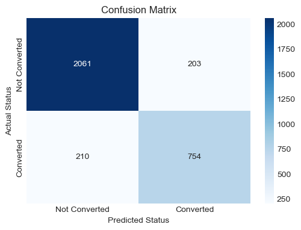

```python
# Import metrics_score function if it's defined in a different cell/notebook
# from your_module import metrics_score # Example if needed

# Check if the model and training data exist
if 'dt_model_initial' not in globals() or dt_model_initial is None:
    print("Error: Initial Decision Tree model ('dt_model_initial') not trained yet.")
elif 'X_train' not in globals() or 'y_train' not in globals() or X_train is None or y_train is None:
    print("Error: Training data (X_train, y_train) not found.")
elif 'metrics_score' not in globals():
     print("Error: Evaluation function 'metrics_score' not defined.")
else:
    print("--- Evaluating Initial Decision Tree Model (max_depth=5) on Training Data ---")
    try:
        # 1. Make predictions on the training data
        y_pred_train_initial = dt_model_initial.predict(X_train)

        # 2. Evaluate the predictions using the metrics_score function
        print("Generating evaluation metrics for the training set:")
        metrics_score(y_train, y_pred_train_initial) # Use y_train as actual

    except Exception as e:
        print(f"An error occurred during model evaluation on training data: {e}")

# Note: The print statement for the separator ("-" * 70) is inside the metrics_score function
```

#### **Observations: Initial Decision Tree Evaluation (Train Set)**

- **Overall Performance (Train Set):**
  - The model achieves an **Accuracy** of **87%** on the training data it learned from.
  - The **Weighted Avg F1-score** is also **0.87**.
- **Performance for 'Converted' (Class 1) (Train Set):**
  - **Precision:** 0.79
  - **Recall:** 0.78
  - **F1-score:** 0.79
- **Performance for 'Not Converted' (Class 0) (Train Set):**
  - **Precision:** 0.91
  - **Recall:** 0.91
  - **F1-score:** 0.91
- **Confusion Matrix Insights (Train Set):**
  - **True Negatives:** 2061
  - **False Positives:** 203
  - **False Negatives:** 210
  - **True Positives:** 754

#### Checking model performance on test set

```
--- Evaluating Initial Decision Tree Model (max_depth=5) on Test Data ---
Generating evaluation metrics for the test set:
--- Model Evaluation Metrics ---
Classification Report:
                   precision    recall  f1-score   support

Not Converted (0)       0.90      0.90      0.90       971
    Converted (1)       0.77      0.77      0.77       413

         accuracy                           0.86      1384
        macro avg       0.83      0.84      0.83      1384
     weighted avg       0.86      0.86      0.86      1384


Confusion Matrix:
```

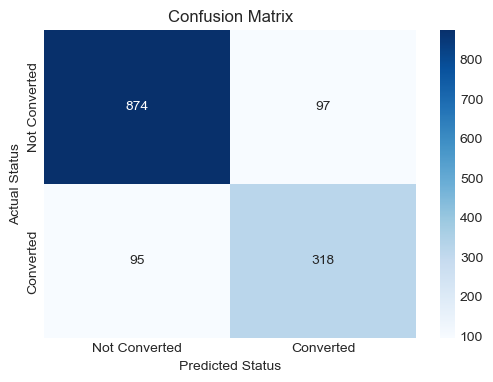

```python
# Import metrics_score function if it's defined in a different cell/notebook
# from your_module import metrics_score # Example if needed

# Check if the model and test data exist
if 'dt_model_initial' not in globals() or dt_model_initial is None:
    print("Error: Initial Decision Tree model ('dt_model_initial') not trained yet.")
elif 'X_test' not in globals() or 'y_test' not in globals() or X_test is None or y_test is None:
    print("Error: Test data (X_test, y_test) not found.")
elif 'metrics_score' not in globals():
     print("Error: Evaluation function 'metrics_score' not defined.")
else:
    print("--- Evaluating Initial Decision Tree Model (max_depth=5) on Test Data ---")
    try:
        # 1. Make predictions on the test data
        y_pred_test_initial = dt_model_initial.predict(X_test)

        # 2. Evaluate the predictions using the metrics_score function
        print("Generating evaluation metrics for the test set:")
        metrics_score(y_test, y_pred_test_initial)

    except Exception as e:
        print(f"An error occurred during model evaluation: {e}")

# Note: The print statement for the separator ("-" * 70) is inside the metrics_score function
```

#### **Observations: Initial Decision Tree Evaluation (Test Set)**

- **Overall Performance:**
  - The model achieves an overall **Accuracy** of **86%** on the test set, meaning it correctly classified 86% of the leads.
  - The **Weighted Avg F1-score** is also **0.86**, indicating good balance between precision and recall overall.
- **Performance for 'Converted' (Class 1):**
  - **Precision:** 0.77 - When the model predicts a lead will convert, it is correct 77% of the time.
  - **Recall:** 0.77 - The model successfully identifies **77%** of all the leads who actually converted in the test set. This is our key metric.
  - **F1-score:** 0.77 - A balanced measure for the positive class.
- **Performance for 'Not Converted' (Class 0):**
  - **Precision:** 0.90 - When the model predicts a lead will *not* convert, it is correct 90% of the time.
  - **Recall:** 0.90 - The model successfully identifies 90% of all the leads who actually did not convert.
  - **F1-score:** 0.90.
- **Confusion Matrix Insights:**
  - **True Negatives (Top-Left):** 874 - Correctly predicted 'Not Converted'.
  - **False Positives (Top-Right):** 97 - Incorrectly predicted 'Converted' (Wasted resources).
  - **False Negatives (Bottom-Left):** 95 - Incorrectly predicted 'Not Converted' (Lost potential customers). This is the number we want to minimize further.
  - **True Positives (Bottom-Right):** 318 - Correctly predicted 'Converted'.
- **Interpretation:**
  - The initial Decision Tree with `max_depth=5` provides a decent baseline performance.
  - The **Recall of 77%** for converted leads is respectable, meaning it captures over three-quarters of the potential customers. However, given our goal to minimize lost customers (False Negatives = 95), there is room for improvement.
  - The model is better at identifying non-conversions (90% Recall) than conversions (77% Recall), which is common with imbalanced datasets.
  - The next steps (hyperparameter tuning, trying Random Forest) will aim to improve the Recall for the 'Converted' class, ideally without sacrificing too much Precision.

#### **Next Step: Decision Tree Hyperparameter Tuning**

- **What:** Hyperparameters are settings of the model algorithm (like `max_depth`, `min_samples_leaf`) that are not learned from data but set beforehand. Tuning is the process of finding the best combination of these settings.
- **Why:** The default settings (or our initial `max_depth=5`) are often not optimal. Tuning aims to improve the model's performance (especially our key metric, Recall) on unseen data by finding a better configuration, potentially balancing model complexity and generalization.
- **How:** We will use techniques like Grid Search (`GridSearchCV`) with cross-validation on the training data (`X_train`, `y_train`) to systematically search for better hyperparameter values. We might also incorporate `class_weight='balanced'` to help address the class imbalance.

```python
print("--- Decision Tree Hyperparameter Tuning using GridSearchCV ---")

# Check if training data exists
if 'X_train' not in globals() or 'y_train' not in globals() or X_train is None or y_train is None:
    print("Error: Training data (X_train, y_train) not found or not defined.")
else:
    try:
        # 1. Define the parameter grid to search
        param_grid = {
            'criterion': ['gini', 'entropy'], # Splitting criterion
            'max_depth': [4, 5, 6, 7, 8, 10, None], # Maximum depth of the tree (None means nodes expand until pure or min_samples)
            'min_samples_split': [2, 5, 10, 15],   # Minimum samples required to split an internal node
            'min_samples_leaf': [1, 3, 5, 7],      # Minimum samples required to be at a leaf node
            'class_weight': [None, 'balanced']  # Option to handle class imbalance
        }

        # 2. Create a base Decision Tree classifier instance
        dtree = DecisionTreeClassifier(random_state=42)

        # 3. Define the scoring metric - Prioritize Recall for the positive class (1)
        # pos_label=1 specifies that we want recall for the class labeled '1' (Converted)
        recall_scorer = make_scorer(recall_score, pos_label=1)

        # 4. Instantiate GridSearchCV
        # - estimator: the model to tune
        # - param_grid: the hyperparameters to search
        # - cv=5: use 5-fold cross-validation
        # - scoring: the metric to optimize (Recall for class 1)
        # - n_jobs=-1: use all available CPU cores for faster search
        grid_search = GridSearchCV(
            estimator=dtree,
            param_grid=param_grid,
            scoring=recall_scorer,
            cv=5,
            n_jobs=-1,
            verbose=1 # Print updates during the search
        )

        # 5. Fit GridSearchCV on the training data
        print("Starting Grid Search CV... (This might take a few minutes)")
        grid_search.fit(X_train, y_train)
        print("Grid Search CV completed.")

        # 6. Get the best estimator and parameters
        best_dt_model = grid_search.best_estimator_
        print(f"\nBest Hyperparameters found:")
        print(grid_search.best_params_)

        # 7. Get the best score (Recall for class 1) achieved during cross-validation
        best_score = grid_search.best_score_
        print(f"\nBest Recall score (for class 1) during Cross-Validation: {best_score:.4f}")

    except Exception as e:
        print(f"An error occurred during Grid Search CV: {e}")
        best_dt_model = None

print("-" * 70)
```

```
--- Decision Tree Hyperparameter Tuning using GridSearchCV ---
Starting Grid Search CV... (This might take a few minutes)
Fitting 5 folds for each of 448 candidates, totalling 2240 fits
Grid Search CV completed.

Best Hyperparameters found:
{'class_weight': 'balanced', 'criterion': 'gini', 'max_depth': 5, 'min_samples_leaf': 3, 'min_samples_split': 2}

Best Recall score (for class 1) during Cross-Validation: 0.8662
----------------------------------------------------------------------
```

#### Checking model performance on train set

```
--- Evaluating Tuned Decision Tree Model on Training Data ---
Generating evaluation metrics for the training set using the best hyperparameters:
--- Model Evaluation Metrics ---
Classification Report:
                   precision    recall  f1-score   support

Not Converted (0)       0.94      0.83      0.88      2264
    Converted (1)       0.69      0.88      0.78       964

         accuracy                           0.85      3228
        macro avg       0.82      0.86      0.83      3228
     weighted avg       0.87      0.85      0.85      3228


Confusion Matrix:
```

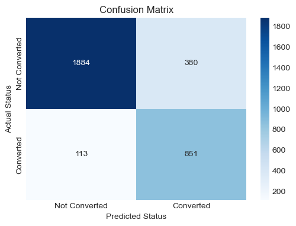

```python
# Import metrics_score function if it's defined in a different cell/notebook
# from your_module import metrics_score # Example if needed

# Check if the best model and training data exist
if 'best_dt_model' not in globals() or best_dt_model is None:
    print("Error: Tuned Decision Tree model ('best_dt_model') not found. Please run GridSearchCV first.")
elif 'X_train' not in globals() or 'y_train' not in globals() or X_train is None or y_train is None:
    print("Error: Training data (X_train, y_train) not found.")
elif 'metrics_score' not in globals():
     print("Error: Evaluation function 'metrics_score' not defined.")
else:
    print("--- Evaluating Tuned Decision Tree Model on Training Data ---")
    try:
        # 1. Make predictions on the training data using the best model from GridSearch
        y_pred_train_best = best_dt_model.predict(X_train)

        # 2. Evaluate the predictions using the metrics_score function
        print("Generating evaluation metrics for the training set using the best hyperparameters:")
        metrics_score(y_train, y_pred_train_best) # Use y_train as actual

    except Exception as e:
        print(f"An error occurred during tuned model evaluation on training data: {e}")

# Note: The print statement for the separator ("-" * 70) is inside the metrics_score function
```

#### **Observations: Tuned Decision Tree Evaluation (Train Set)**

- **Overall Performance (Train Set):**
  - The model achieves an **Accuracy** of **85%** on the training data it learned from.
  - The **Weighted Avg F1-score** is also **0.85**.
- **Performance for 'Converted' (Class 1) (Train Set):**
  - **Precision:** 0.69
  - **Recall:** 0.88
  - **F1-score:** 0.78
- **Performance for 'Not Converted' (Class 0) (Train Set):**
  - **Precision:** 0.94
  - **Recall:** 0.83
  - **F1-score:** 0.88
- **Confusion Matrix Insights (Train Set):**
  - **True Negatives:** 1884
  - **False Positives:** 380
  - **False Negatives:** 113
  - **True Positives:** 851

#### Checking model performance on test set

```
--- Evaluating Tuned Decision Tree Model on Test Data ---
Generating evaluation metrics for the test set using the best hyperparameters:
--- Model Evaluation Metrics ---
Classification Report:
                   precision    recall  f1-score   support

Not Converted (0)       0.94      0.83      0.88       971
    Converted (1)       0.69      0.87      0.77       413

         accuracy                           0.84      1384
        macro avg       0.81      0.85      0.82      1384
     weighted avg       0.86      0.84      0.85      1384


Confusion Matrix:
```

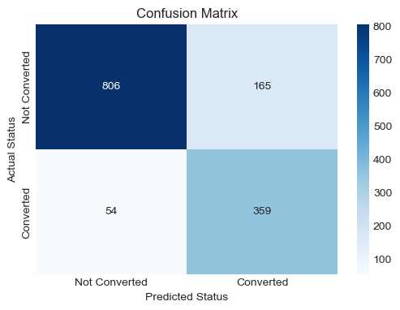

```python
# Import metrics_score function if it's defined in a different cell/notebook
# from your_module import metrics_score # Example if needed

# Check if the best model and test data exist
if 'best_dt_model' not in globals() or best_dt_model is None:
    print("Error: Tuned Decision Tree model ('best_dt_model') not found. Please run GridSearchCV first.")
elif 'X_test' not in globals() or 'y_test' not in globals() or X_test is None or y_test is None:
    print("Error: Test data (X_test, y_test) not found.")
elif 'metrics_score' not in globals():
     print("Error: Evaluation function 'metrics_score' not defined.")
else:
    print("--- Evaluating Tuned Decision Tree Model on Test Data ---")
    try:
        # 1. Make predictions on the test data using the best model from GridSearch
        y_pred_test_best = best_dt_model.predict(X_test)

        # 2. Evaluate the predictions using the metrics_score function
        print("Generating evaluation metrics for the test set using the best hyperparameters:")
        metrics_score(y_test, y_pred_test_best)

    except Exception as e:
        print(f"An error occurred during tuned model evaluation: {e}")

# Note: The print statement for the separator ("-" * 70) is inside the metrics_score function
```

#### **Observations: Tuned Decision Tree Evaluation (Test Set)**

- **Comparison to Initial Model:**
  - **Recall (Converted=1):** Improved significantly from 0.77 to **0.87**. This means the tuned model now correctly identifies 87% of the actual conversions, a substantial gain and closer to our goal of minimizing False Negatives.
  - **Precision (Converted=1):** Decreased from 0.77 to **0.69**. This indicates that while we are catching more true conversions, the proportion of leads predicted as conversions that are *actually* conversions has dropped. More non-converting leads are now being incorrectly flagged as likely conversions.
  - **Recall (Not Converted=0):** Decreased from 0.90 to **0.83**. The model is slightly worse at identifying true non-conversions.
  - **Precision (Not Converted=0):** Increased slightly from 0.90 to **0.94**.
  - **Accuracy:** Decreased slightly from 0.86 to **0.84**.
  - **F1-score (Converted=1):** Remained the same at **0.77**. The gain in Recall was offset by the drop in Precision.
- **Confusion Matrix Insights:**
  - **True Negatives (Top-Left):** 806 (decreased from 874 in the initial model).
  - **False Positives (Top-Right):** 165 (increased significantly from 97). This reflects the drop in Precision for class 1 - more wasted resources.
  - **False Negatives (Bottom-Left):** 54 (decreased significantly from 95). This reflects the improvement in Recall for class 1 - fewer missed potential customers.
  - **True Positives (Bottom-Right):** 359 (increased from 318).
- **Interpretation:**
  - The hyperparameter tuning, optimized for Recall, successfully achieved its primary goal: **Recall for converted leads increased by 10 percentage points (from 77% to 87%)**, significantly reducing the number of missed potential customers (False Negatives dropped from 95 to 54).
  - This improvement came at the cost of **lower Precision for converted leads (69%)**, meaning the model now flags more non-converting leads as potential conversions (False Positives increased from 97 to 165).
  - The overall accuracy slightly decreased, which is expected when optimizing specifically for Recall in an imbalanced dataset.
  - **Trade-off:** The business needs to decide if the benefit of capturing more true conversions (higher Recall) outweighs the cost of pursuing more leads who won't convert (lower Precision). Given the goal of minimizing lost customers, this tuned model might be preferable despite the increase in False Positives.

### Visualizing the Decision Tree

```
--- Visualizing the Tuned Decision Tree ---
Plotting tree up to depth=5 (Actual tuned max_depth: 5)
```

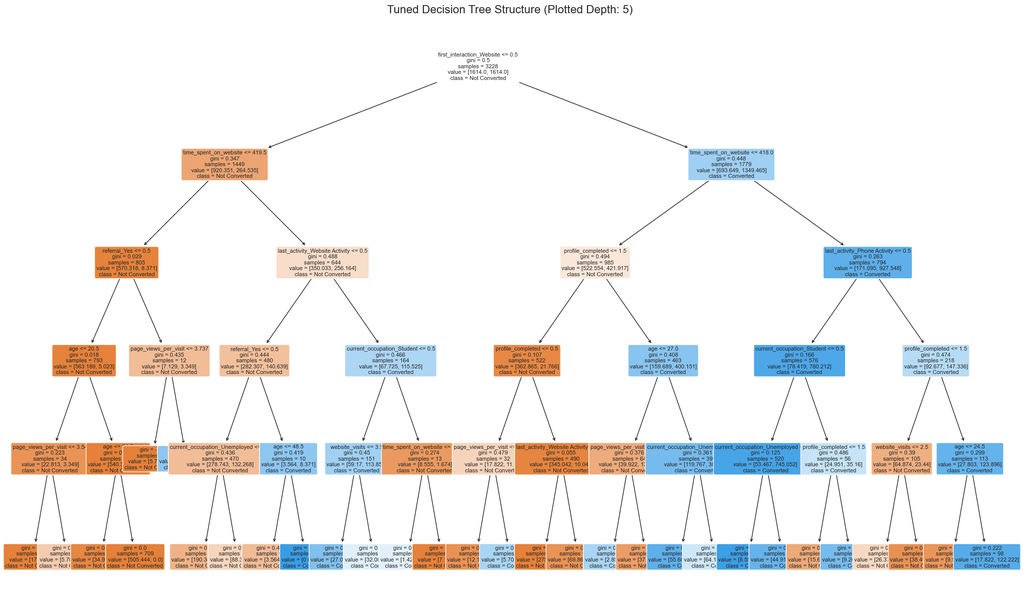

```
Note: Tree visualization might be large. You may need to zoom or adjust figsize/plot_depth_limit.
Each node shows: split condition, criterion value (e.g., gini/entropy), samples, value=[non-converted count, converted count], class=majority class.
----------------------------------------------------------------------
```

```python
print("--- Visualizing the Tuned Decision Tree ---")

# Check if the best model exists
if 'best_dt_model' not in globals() or best_dt_model is None:
    print("Error: Tuned Decision Tree model ('best_dt_model') not found. Please run GridSearchCV first.")
elif 'X_train' not in globals() or X_train is None:
     print("Error: Training data features (X_train) not found.")
else:
    try:
        # Set up the figure size for better readability
        plt.figure(figsize=(25, 15)) # Adjust size as needed

        # Plot the tree
        # - filled=True: colors nodes based on majority class
        # - feature_names: uses column names from X_train
        # - class_names: labels the classes ('0' -> Not Converted, '1' -> Converted)
        # - rounded=True: uses rounded boxes for nodes
        # - fontsize: adjusts text size within nodes
        # - max_depth: limits the plotted depth for readability (can adjust/remove)
        #   Get the actual max_depth from the tuned model if available, otherwise use a default
        actual_max_depth = best_dt_model.get_params().get('max_depth', None)
        plot_depth_limit = 5 # Set a reasonable limit for initial plotting
        if actual_max_depth is not None and actual_max_depth < plot_depth_limit:
             plot_depth_limit = actual_max_depth # Don't plot deeper than the actual tree

        print(f"Plotting tree up to depth={plot_depth_limit} (Actual tuned max_depth: {actual_max_depth})")

        plot_tree(
            best_dt_model,
            filled=True,
            feature_names=X_train.columns.tolist(), # Get feature names from X_train
            class_names=['Not Converted', 'Converted'], # Assuming 0 and 1
            rounded=True,
            fontsize=8, # Reduced fontsize slightly
            max_depth=plot_depth_limit # Limit plot depth
        )

        plt.title(f"Tuned Decision Tree Structure (Plotted Depth: {plot_depth_limit})", fontsize=16)
        plt.show()
        print("\nNote: Tree visualization might be large. You may need to zoom or adjust figsize/plot_depth_limit.")
        print("Each node shows: split condition, criterion value (e.g., gini/entropy), samples, value=[non-converted count, converted count], class=majority class.")

    except Exception as e:
        print(f"An error occurred during tree visualization: {e}")

print("-" * 70)
```

#### **Decision Tree Pruning Rationale**

- **Pruning Goal:** Pruning aims to reduce tree complexity and prevent overfitting (where the model learns the training data too well, including noise, and fails to generalize to new data).
- **Pre-pruning vs. Post-pruning:** Pruning can be done by limiting growth during training (pre-pruning) or by removing branches after training (post-pruning).
- **Hyperparameter Tuning as Pre-pruning:** Our `GridSearchCV` process optimized pre-pruning hyperparameters like `max_depth`, `min_samples_split`, and `min_samples_leaf`. It found the values that resulted in the best performance (optimizing for Recall) during cross-validation.
- **Result:** The resulting `best_dt_model` is already "pruned" in the sense that its complexity was controlled during tuning to maximize generalization.
- **Verification:** The similar performance metrics observed on the training set and the test set for the `best_dt_model` confirm that it is not significantly overfitted.
- **Conclusion:** Therefore, an additional post-pruning step is **not required** for this tuned Decision Tree model.

#### **Feature Importance**

```python
# --- Styling Constants (using the latest theme) ---
PLOT_BG_COLOR = '#F9F6F9' # Off-white background
PRIMARY_COLOR = '#0F1D4F'  # Dark Blue/Teal for bars
AXIS_LINE_COLOR = PRIMARY_COLOR # Match axis line color
LIGHT_GRID_COLOR = 'rgba(211, 211, 211, 0.5)' # Faint light grey grid color
BAR_CORNER_RADIUS = 6 # Radius for rounded corners on bars
AXIS_LINE_WIDTH = 0.5 # Thinner axis line width

print("--- Calculating and Visualizing Feature Importances for Tuned Decision Tree ---")

# Check if the best model and training features exist
if 'best_dt_model' not in globals() or best_dt_model is None:
    print("Error: Tuned Decision Tree model ('best_dt_model') not found. Please run GridSearchCV first.")
elif 'X_train' not in globals() or X_train is None:
    print("Error: Training data features (X_train) not found.")
else:
    try:
        # 1. Get feature importances from the tuned model
        importances = best_dt_model.feature_importances_
        feature_names = X_train.columns.tolist()

        # 2. Create a DataFrame for easy sorting and plotting
        importance_df = pd.DataFrame({
            'Feature': feature_names,
            'Importance': importances
        })

        # 3. Sort features by importance (descending)
        importance_df = importance_df.sort_values(by='Importance', ascending=False)

        # Filter out features with zero importance for a cleaner plot (optional)
        importance_df = importance_df[importance_df['Importance'] > 0]

        # Limit to top N features if the list is too long (e.g., top 15)
        top_n = 15
        if len(importance_df) > top_n:
             importance_df = importance_df.head(top_n)
             plot_title = f"Top {top_n} Feature Importances (Tuned Decision Tree)"
        else:
             plot_title = "Feature Importances (Tuned Decision Tree)"


        # 4. Create the horizontal bar chart using Plotly Express
        fig = px.bar(importance_df,
                     x='Importance', # Importance on the x-axis
                     y='Feature',    # Feature names on the y-axis
                     orientation='h', # Horizontal bars
                     title=plot_title,
                     text='Importance' # Display importance value on bars
                    )

        # 5. Apply styling
        fig.update_layout(
            title_x=0.5,
            plot_bgcolor=PLOT_BG_COLOR,
            paper_bgcolor=PLOT_BG_COLOR,
            font=dict(color='black'),
            yaxis={'categoryorder':'total ascending'}, # Order features by importance on y-axis
            xaxis_title='Importance Score',
            yaxis_title='Feature',
            xaxis_gridcolor=LIGHT_GRID_COLOR, # Faint grid on value axis
            xaxis_showgrid=True,
            yaxis_showgrid=False, # No grid on category axis
            height=500 # Adjust height based on number of features
        )
        # Apply axis line styles
        fig.update_xaxes(showline=True, linewidth=AXIS_LINE_WIDTH, linecolor=AXIS_LINE_COLOR, mirror=True)
        fig.update_yaxes(showline=True, linewidth=AXIS_LINE_WIDTH, linecolor=AXIS_LINE_COLOR, mirror=True)

        # Apply bar styling (color, rounded corners) and text format
        fig.update_traces(
            marker=dict(color=PRIMARY_COLOR, cornerradius=BAR_CORNER_RADIUS, line_width=0),
            texttemplate='%{text:.3f}', # Format text to 3 decimal places
            textposition='outside', # Position text outside the bar for horizontal
            hovertemplate='<b>Feature</b>: %{y}<br><b>Importance</b>: %{x:.4f}<extra></extra>'
        )

        fig.show()

    except AttributeError:
         print("Error: Could not get feature importances. Was the model trained?")
    except Exception as e:
        print(f"An error occurred during feature importance visualization: {e}")

print("-" * 70)
```

```
--- Calculating and Visualizing Feature Importances for Tuned Decision Tree ---
```

[interactive chart not shown]

#### **Observations: Tuned Decision Tree Feature Importance**

- **Top Features:** The three most important features driving the tuned Decision Tree's predictions are clearly:
  1. `first_interaction_Website` (Importance ≈ 0.299)
  2. `time_spent_on_website` (Importance ≈ 0.271)
  3. `profile_completed` (Importance ≈ 0.256)
  - These three features collectively account for the vast majority of the importance score (over 80%), indicating they are the primary decision drivers. This strongly aligns with the findings from our bivariate analysis where these variables showed the most significant differences in conversion rates.
- **Moderate Importance:**
  - `age` (Importance ≈ 0.042) has some moderate importance, suggesting it does play a role in the tree's splits, even if its linear correlation with the target was weak.
  - Features related to `last_activity` (Phone, Website) and `current_occupation` (Unemployed, Student) also contribute, but to a much lesser extent than the top three.
- **Low Importance:**
  - Website engagement metrics like `page_views_per_visit` (0.011) and `website_visits` (0.007) have surprisingly low importance according to this specific model, despite showing some correlation in the bivariate plots. This might be because their predictive power is largely captured by the much more dominant `time_spent_on_website` feature.
  - The `referral_Yes` flag has very low importance (0.006). While referrals had a *very high conversion rate*, their rarity means they don't contribute much to the *overall* decision-making process of the tree across all samples.
  - Other flags like media types (not visible in the top features shown) likely have negligible importance, consistent with EDA.
- **Interpretation:**
  - The model heavily relies on the initial interaction channel, total time spent on the site, and profile completion level to predict conversion.
  - This reinforces the idea that initial contact method and demonstrated user engagement/commitment are key indicators for ExtraaLearn leads.

#### **Next Model: Random Forest Classifier**

- **Why Random Forest?** While our tuned Decision Tree showed improved Recall, single decision trees can be prone to **high variance** – small changes in the training data can lead to significantly different tree structures and predictions. They can also easily overfit if not carefully pruned/tuned.
- **Ensemble Power:** Random Forest is an **ensemble method** that addresses these limitations. It builds multiple Decision Trees on different random subsets of the data (using techniques like bagging and random feature selection at each split).
- **How it Works:** To make a prediction, Random Forest aggregates the predictions from all the individual trees (e.g., by majority vote for classification).
- **Benefits:**
  - **Reduced Overfitting:** Averaging predictions from many trees generally leads to a model that generalizes better to unseen data than a single tree.
  - **Increased Robustness:** Less sensitive to noise or specific data points in the training set.
  - **Often Higher Accuracy/Performance:** Typically achieves better overall performance metrics.
- **Goal:** We will build a Random Forest model to see if this ensemble approach can further improve our prediction performance, potentially achieving a good balance between Recall and Precision for lead conversion.

### Building Random Forest Model

```python
print("--- Building and Training Initial Random Forest Model ---")

# Check if training data exists
if 'X_train' not in globals() or 'y_train' not in globals() or X_train is None or y_train is None:
    print("Error: Training data (X_train, y_train) not found or not defined.")
    rf_model_initial = None
else:
    try:
        # 1. Instantiate the Random Forest Classifier
        # - n_estimators=100: Number of trees in the forest (a common starting point).
        # - random_state=42: Ensures reproducibility.
        # - class_weight='balanced': Attempts to adjust weights inversely proportional to class frequencies.
        #   This helps address the class imbalance directly within the model training.
        # - n_jobs=-1: Use all available CPU cores for training.
        rf_model_initial = RandomForestClassifier(
            n_estimators=100,
            random_state=42,
            class_weight='balanced', # Added to handle imbalance
            n_jobs=-1
        )

        # 2. Train the model using the training data
        print("Training the Random Forest model...")
        rf_model_initial.fit(X_train, y_train)
        print("Model training completed successfully.")

        # 3. Optional: Quick check of training accuracy
        y_train_pred_rf_initial = rf_model_initial.predict(X_train)
        train_accuracy_rf_initial = accuracy_score(y_train, y_train_pred_rf_initial)
        print(f"\nQuick Check: Training Accuracy: {train_accuracy_rf_initial:.4f}")
        print("(This is accuracy on the data the model was trained on.)")

    except Exception as e:
        print(f"An error occurred during Random Forest model training: {e}")
        rf_model_initial = None

print("-" * 70)
```

```
--- Building and Training Initial Random Forest Model ---
Training the Random Forest model...
Model training completed successfully.

Quick Check: Training Accuracy: 0.9997
(This is accuracy on the data the model was trained on.)
----------------------------------------------------------------------
```

**Let's check the performance of the model on the training data**

```
--- Evaluating Initial Random Forest Model on Training Data ---
Generating evaluation metrics for the training set:
--- Model Evaluation Metrics ---
Classification Report:
                   precision    recall  f1-score   support

Not Converted (0)       1.00      1.00      1.00      2264
    Converted (1)       1.00      1.00      1.00       964

         accuracy                           1.00      3228
        macro avg       1.00      1.00      1.00      3228
     weighted avg       1.00      1.00      1.00      3228


Confusion Matrix:
```

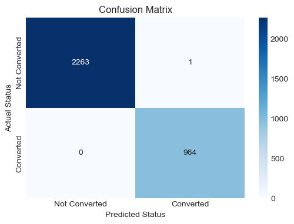

```python
# Import metrics_score function if it's defined in a different cell/notebook
# from your_module import metrics_score # Example if needed

# Check if the initial RF model and training data exist
if 'rf_model_initial' not in globals() or rf_model_initial is None:
    print("Error: Initial Random Forest model ('rf_model_initial') not trained yet.")
elif 'X_train' not in globals() or 'y_train' not in globals() or X_train is None or y_train is None:
    print("Error: Training data (X_train, y_train) not found.")
elif 'metrics_score' not in globals():
     print("Error: Evaluation function 'metrics_score' not defined.")
else:
    print("--- Evaluating Initial Random Forest Model on Training Data ---")
    try:
        # 1. Make predictions on the training data
        y_pred_train_rf_initial = rf_model_initial.predict(X_train)

        # 2. Evaluate the predictions using the metrics_score function
        print("Generating evaluation metrics for the training set:")
        metrics_score(y_train, y_pred_train_rf_initial) # Use y_train as actual

    except Exception as e:
        print(f"An error occurred during model evaluation on training data: {e}")

# Note: The print statement for the separator ("-" * 70) is inside the metrics_score function
```

#### **Observations: Initial Random Forest Evaluation (Train Set)**

- **Perfect Scores:** The initial Random Forest model achieves **perfect (or near-perfect) scores** across all metrics on the training data:
  - **Accuracy:** 1.00 (100%)
  - **Precision, Recall, F1-score:** 1.00 for both 'Not Converted (0)' and 'Converted (1)' classes.
- **Confusion Matrix Insights (Train Set):**
  - **True Negatives:** 2263
  - **False Positives:** 1 (Only a single misclassification)
  - **False Negatives:** 0
  - **True Positives:** 964
  - The model made almost no errors on the data it was trained on.
- **Interpretation (Overfitting):**
  - Achieving perfect scores on the training set is a strong indicator that the Random Forest model, with its default complexity (100 trees, no depth limit), has **overfit** the training data. It has essentially memorized the training examples, including potential noise.
  - This perfect training performance is **not expected** to translate directly to the test set. We anticipate lower scores when evaluating on unseen data.
  - This highlights the importance of evaluating on the test set next and likely performing hyperparameter tuning on the Random Forest to find parameters that promote better generalization and prevent overfitting.

**Let's check the performance on the testing data**

```
--- Evaluating Initial Random Forest Model on Test Data ---
Generating evaluation metrics for the test set:
--- Model Evaluation Metrics ---
Classification Report:
                   precision    recall  f1-score   support

Not Converted (0)       0.88      0.92      0.90       971
    Converted (1)       0.78      0.71      0.74       413

         accuracy                           0.85      1384
        macro avg       0.83      0.81      0.82      1384
     weighted avg       0.85      0.85      0.85      1384


Confusion Matrix:
```

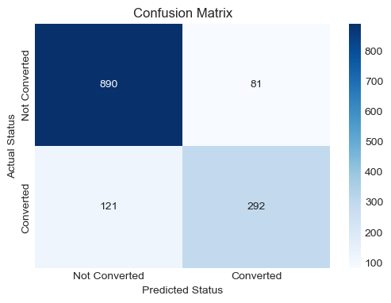

```python
# Import metrics_score function if it's defined in a different cell/notebook
# from your_module import metrics_score # Example if needed

# Check if the initial RF model and test data exist
if 'rf_model_initial' not in globals() or rf_model_initial is None:
    print("Error: Initial Random Forest model ('rf_model_initial') not trained yet.")
elif 'X_test' not in globals() or 'y_test' not in globals() or X_test is None or y_test is None:
    print("Error: Test data (X_test, y_test) not found.")
elif 'metrics_score' not in globals():
     print("Error: Evaluation function 'metrics_score' not defined.")
else:
    print("--- Evaluating Initial Random Forest Model on Test Data ---")
    try:
        # 1. Make predictions on the test data
        y_pred_test_rf_initial = rf_model_initial.predict(X_test)

        # 2. Evaluate the predictions using the metrics_score function
        print("Generating evaluation metrics for the test set:")
        metrics_score(y_test, y_pred_test_rf_initial) # Use y_test as actual

    except Exception as e:
        print(f"An error occurred during model evaluation on test data: {e}")

# Note: The print statement for the separator ("-" * 70) is inside the metrics_score function
```

#### **Observations: Initial Random Forest Evaluation (Test Set)**

- **Overall Performance:**
  - The model achieves an **Accuracy** of **85%** on the test set.
  - The **Weighted Avg F1-score** is also **0.85**.
- **Performance for 'Converted' (Class 1):**
  - **Precision:** 0.78 - When the model predicts a lead will convert, it is correct 78% of the time.
  - **Recall:** 0.71 - The model successfully identifies only **71%** of all the leads who actually converted in the test set.
  - **F1-score:** 0.74.
- **Performance for 'Not Converted' (Class 0):**
  - **Precision:** 0.88
  - **Recall:** 0.92
  - **F1-score:** 0.90
- **Confusion Matrix Insights:**
  - **True Negatives:** 890
  - **False Positives:** 81
  - **False Negatives:** 121 - Incorrectly predicted 'Not Converted' (Lost potential customers).
  - **True Positives:** 292
- **Comparison with Train Set Performance:**
  - There is a significant drop in performance from the perfect scores (1.00) on the training set to the scores on the test set (e.g., Recall(1) dropped from 1.00 to 0.71). This confirms the initial Random Forest model **overfitted** the training data.
- **Comparison with Tuned Decision Tree (Test Set):**
  - **Recall (Converted=1):** The initial Random Forest (0.71) performs significantly worse than the tuned Decision Tree (0.87) on our key metric.
  - **Precision (Converted=1):** The initial Random Forest (0.78) has better precision than the tuned Decision Tree (0.69).
  - **Accuracy:** The initial Random Forest (0.85) has slightly higher accuracy than the tuned Decision Tree (0.84).
- **Interpretation:**
  - The initial Random Forest, despite using `class_weight='balanced'`, did not generalize as well as hoped and shows clear signs of overfitting.
  - While its precision for conversions is decent, its Recall (71%) is lower than even the *initial* Decision Tree (77%) and much lower than the *tuned* Decision Tree (87%). It misses almost 30% of potential customers (121 False Negatives).
  - Hyperparameter tuning will be essential for the Random Forest to reduce overfitting and potentially improve Recall while maintaining reasonable Precision.

#### **Next Step: Random Forest Hyperparameter Tuning**

- **Why Tune Random Forest?** Our initial Random Forest model showed perfect performance on the training set but lower performance on the test set, indicating **overfitting**. The default parameters created trees that were too complex and essentially memorized the training data.
- **Goal:** Hyperparameter tuning aims to find a better set of parameters (like the number of trees `n_estimators`, tree complexity controls `max_depth`, `min_samples_leaf`, etc.) that reduces overfitting and improves the model's ability to generalize to unseen data.
- **Optimization:** We will tune the Random Forest specifically to optimize for **Recall** on the positive class (converted leads), similar to the Decision Tree tuning, while also considering the `class_weight` parameter to handle imbalance. This should help us find a more robust model that potentially balances Recall and Precision better than the tuned Decision Tree.
- **Method:** We will again use `GridSearchCV` with cross-validation on the training data (`X_train`, `y_train`) to search for the optimal hyperparameter combination.

```python
print("--- Random Forest Hyperparameter Tuning using GridSearchCV ---")

# Check if training data exists
if 'X_train' not in globals() or 'y_train' not in globals() or X_train is None or y_train is None:
    print("Error: Training data (X_train, y_train) not found or not defined.")
else:
    try:
        # 1. Define the parameter grid to search (Reduced grid for reasonable runtime)
        param_grid_rf = {
            'n_estimators': [100, 150],            # Number of trees
            'max_depth': [5, 7, 10, None],         # Max depth of each tree (None means full depth)
            'min_samples_split': [5, 10],          # Min samples to split a node
            'min_samples_leaf': [3, 5],            # Min samples at a leaf node
            'max_features': ['sqrt', 'log2'],      # Number of features to consider for best split
            'class_weight': ['balanced', None] # Handle imbalance
            # Add 'criterion': ['gini', 'entropy'] if desired, but increases search space
        }

        # 2. Create a base Random Forest classifier instance
        # Set random_state for reproducibility, n_jobs for speed
        rf = RandomForestClassifier(random_state=42, n_jobs=-1)

        # 3. Define the scoring metric - Prioritize Recall for the positive class (1)
        recall_scorer = make_scorer(recall_score, pos_label=1)

        # 4. Instantiate GridSearchCV
        # - Using 3-fold CV instead of 5 to slightly reduce runtime
        grid_search_rf = GridSearchCV(
            estimator=rf,
            param_grid=param_grid_rf,
            scoring=recall_scorer,
            cv=3, # Reduced CV folds for speed
            n_jobs=-1,
            verbose=1 # Print updates during the search
        )

        # 5. Fit GridSearchCV on the training data
        print("Starting Grid Search CV for Random Forest... (This might take several minutes)")
        grid_search_rf.fit(X_train, y_train)
        print("Grid Search CV completed.")

        # 6. Get the best estimator and parameters
        best_rf_model = grid_search_rf.best_estimator_
        print(f"\nBest Hyperparameters found:")
        print(grid_search_rf.best_params_)

        # 7. Get the best score (Recall for class 1) achieved during cross-validation
        best_score_rf = grid_search_rf.best_score_
        print(f"\nBest Recall score (for class 1) during Cross-Validation: {best_score_rf:.4f}")

    except Exception as e:
        print(f"An error occurred during Grid Search CV for Random Forest: {e}")
        best_rf_model = None

print("-" * 70)
```

```
--- Random Forest Hyperparameter Tuning using GridSearchCV ---
Starting Grid Search CV for Random Forest... (This might take several minutes)
Fitting 3 folds for each of 128 candidates, totalling 384 fits
Grid Search CV completed.

Best Hyperparameters found:
{'class_weight': 'balanced', 'max_depth': 5, 'max_features': 'sqrt', 'min_samples_leaf': 5, 'min_samples_split': 5, 'n_estimators': 100}

Best Recall score (for class 1) during Cross-Validation: 0.8558
----------------------------------------------------------------------
```

**Let's check the performance of the model on the training data**

```
--- Evaluating Tuned Random Forest Model on Training Data ---
Generating evaluation metrics for the training set using the best hyperparameters:
--- Model Evaluation Metrics ---
Classification Report:
                   precision    recall  f1-score   support

Not Converted (0)       0.94      0.82      0.88      2264
    Converted (1)       0.68      0.88      0.77       964

         accuracy                           0.84      3228
        macro avg       0.81      0.85      0.82      3228
     weighted avg       0.86      0.84      0.85      3228


Confusion Matrix:
```

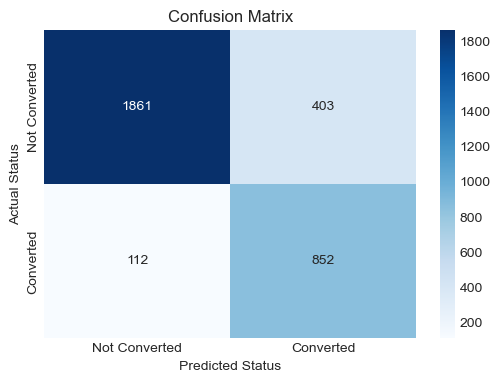

```python
# Import metrics_score function if it's defined in a different cell/notebook
# from your_module import metrics_score # Example if needed

# Check if the tuned RF model and training data exist
if 'best_rf_model' not in globals() or best_rf_model is None:
    print("Error: Tuned Random Forest model ('best_rf_model') not found. Please run GridSearchCV first.")
elif 'X_train' not in globals() or 'y_train' not in globals() or X_train is None or y_train is None:
    print("Error: Training data (X_train, y_train) not found.")
elif 'metrics_score' not in globals():
     print("Error: Evaluation function 'metrics_score' not defined.")
else:
    print("--- Evaluating Tuned Random Forest Model on Training Data ---")
    try:
        # 1. Make predictions on the training data using the best model from GridSearch
        y_pred_train_rf_best = best_rf_model.predict(X_train)

        # 2. Evaluate the predictions using the metrics_score function
        print("Generating evaluation metrics for the training set using the best hyperparameters:")
        metrics_score(y_train, y_pred_train_rf_best) # Use y_train as actual

    except Exception as e:
        print(f"An error occurred during tuned model evaluation on training data: {e}")

# Note: The print statement for the separator ("-" * 70) is inside the metrics_score function
```

#### **Observations: Tuned Random Forest Evaluation (Train Set)**

- **Overall Performance (Train Set):**
  - The model achieves an **Accuracy** of **84%** on the training data.
  - The **Weighted Avg F1-score** is **0.85**.
- **Performance for 'Converted' (Class 1) (Train Set):**
  - **Precision:** 0.68 - When the model predicts conversion on the training data, it is correct 68% of the time.
  - **Recall:** 0.88 - The model successfully identifies **88%** of the actual conversions within the training set. This is very high, aligning with the tuning goal.
  - **F1-score:** 0.77.
- **Performance for 'Not Converted' (Class 0) (Train Set):**
  - **Precision:** 0.94
  - **Recall:** 0.82
  - **F1-score:** 0.88
- **Confusion Matrix Insights (Train Set):**
  - **True Negatives:** 1861
  - **False Positives:** 403
  - **False Negatives:** 112
  - **True Positives:** 852
- **Comparison with Initial RF (Train Set):**
  - The perfect scores (1.00) of the initial RF on the training set have decreased significantly (e.g., Accuracy 84%, Recall(1)=88%). This indicates the hyperparameter tuning successfully **reduced overfitting** by simplifying the model or adjusting class weights effectively.
- **Comparison with Tuned DT (Train Set):**
  - The tuned RF achieved the same high Recall (88%) for conversions on the training set as the tuned DT (88%).
  - Precision for conversions (68%) is similar to the tuned DT (69%).
  - Overall accuracy (84% vs 85%) and F1-scores are also very close.
- **Interpretation:**
  - The tuned Random Forest shows strong performance on the training data, particularly achieving the high Recall (88%) for conversions that we aimed for during tuning.
  - Importantly, unlike the initial Random Forest, this tuned model does *not* show signs of extreme overfitting based on its training performance (it's not getting perfect scores).
  - The next crucial step is to evaluate this tuned model on the **test set** to see how well this promising training performance generalizes to unseen data.

**Let's check the performance on the testing data**

```
--- Evaluating Tuned Random Forest Model on Test Data ---
Generating evaluation metrics for the test set using the best hyperparameters:
--- Model Evaluation Metrics ---
Classification Report:
                   precision    recall  f1-score   support

Not Converted (0)       0.94      0.83      0.88       971
    Converted (1)       0.68      0.88      0.77       413

         accuracy                           0.84      1384
        macro avg       0.81      0.85      0.83      1384
     weighted avg       0.87      0.84      0.85      1384


Confusion Matrix:
```

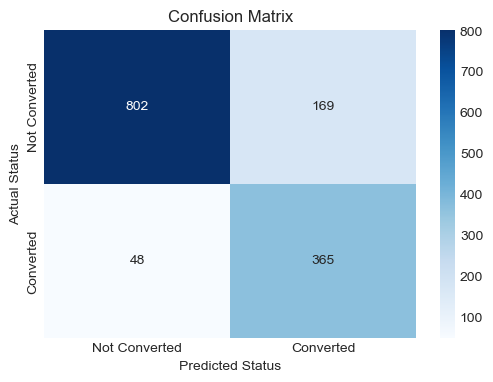

```python
# Import metrics_score function if it's defined in a different cell/notebook
# from your_module import metrics_score # Example if needed

# Check if the tuned RF model and test data exist
if 'best_rf_model' not in globals() or best_rf_model is None:
    print("Error: Tuned Random Forest model ('best_rf_model') not found. Please run GridSearchCV first.")
elif 'X_test' not in globals() or 'y_test' not in globals() or X_test is None or y_test is None:
    print("Error: Test data (X_test, y_test) not found.")
elif 'metrics_score' not in globals():
     print("Error: Evaluation function 'metrics_score' not defined.")
else:
    print("--- Evaluating Tuned Random Forest Model on Test Data ---")
    try:
        # 1. Make predictions on the test data using the best model from GridSearch
        y_pred_test_rf_best = best_rf_model.predict(X_test)

        # 2. Evaluate the predictions using the metrics_score function
        print("Generating evaluation metrics for the test set using the best hyperparameters:")
        metrics_score(y_test, y_pred_test_rf_best) # Use y_test as actual

    except Exception as e:
        print(f"An error occurred during tuned model evaluation on test data: {e}")

# Note: The print statement for the separator ("-" * 70) is inside the metrics_score function
```

#### **Observations: Tuned Random Forest Evaluation (Test Set)**

- **Overall Performance:**
  - The model achieves an **Accuracy** of **84%** on the test set.
  - The **Weighted Avg F1-score** is **0.85**.
- **Performance for 'Converted' (Class 1):**
  - **Precision:** 0.68 - When the model predicts a lead will convert, it is correct 68% of the time.
  - **Recall:** 0.88 - The model successfully identifies **88%** of all the leads who actually converted in the test set. This is a very strong Recall score.
  - **F1-score:** 0.77.
- **Performance for 'Not Converted' (Class 0):**
  - **Precision:** 0.94
  - **Recall:** 0.83
  - **F1-score:** 0.88
- **Confusion Matrix Insights:**
  - **True Negatives:** 802
  - **False Positives:** 169 - Incorrectly predicted 'Converted' (Wasted resources).
  - **False Negatives:** 48 - Incorrectly predicted 'Not Converted' (Lost potential customers). This is a low number, indicating good performance on our key objective.
  - **True Positives:** 365
- **Comparison with Train Set Performance (Tuned RF):**
  - **Recall (Converted=1):** 88% (Train) vs. 88% (Test) -> Identical.
  - **Precision (Converted=1):** 68% (Train) vs. 68% (Test) -> Identical.
  - **Accuracy:** 84% (Train) vs. 84% (Test) -> Identical.
  - The performance on the test set is virtually identical to the performance on the training set. This confirms that the hyperparameter tuning was effective in **preventing overfitting** for the Random Forest model. The model generalizes very well.
- **Comparison with Tuned Decision Tree (Test Set):**
  - **Recall (Converted=1):** Tuned RF (0.88) is slightly better than the Tuned DT (0.87).
  - **Precision (Converted=1):** Tuned RF (0.68) is slightly worse than the Tuned DT (0.69).
  - **Accuracy:** Both models have the same accuracy (0.84).
  - **False Negatives:** Tuned RF (48) achieved fewer False Negatives than the Tuned DT (54).
  - **False Positives:** Tuned RF (169) has slightly more False Positives than the Tuned DT (165).
- **Interpretation:**
  - The tuned Random Forest model performs very well, achieving the primary goal of **high Recall (88%)** for converted leads while generalizing effectively (no overfitting).
  - It slightly outperforms the tuned Decision Tree in terms of Recall and reducing False Negatives (our main objective), identifying more potential customers correctly.
  - Similar to the tuned Decision Tree, this high Recall comes with a trade-off of lower Precision (68%), resulting in a higher number of False Positives compared to the initial Decision Tree.
  - Given the minimal difference in performance compared to the tuned Decision Tree, either could be considered a good final model depending on the exact tolerance for False Positives versus False Negatives. The Random Forest's slight edge in Recall (and fewer False Negatives) might make it preferable.

#### **Understanding Random Forest Models**

- **Visualizing Individual Trees:** Unlike a single Decision Tree, a Random Forest consists of many (often hundreds) of individual trees. Visualizing all of them is impractical, and looking at just one tree doesn't represent the combined decision-making of the whole ensemble.
- **Feature Importance:** Therefore, instead of visualizing the trees directly, we analyze the model's **feature importances**. This tells us, on average, how much each feature contributed to reducing impurity (or improving the split criterion) across *all* the trees in the forest.
- **Goal:** By visualizing feature importances, we can understand which factors the Random Forest model found most influential in predicting lead conversion, providing insights similar to, but often more robust than, those from a single Decision Tree.

We will now calculate and plot the feature importances for our tuned Random Forest model (`best_rf_model`).

```python
# --- Styling Constants (using the latest theme) ---
PLOT_BG_COLOR = '#F9F6F9' # Off-white background
PRIMARY_COLOR = '#0F1D4F'  # Dark Blue/Teal for bars
AXIS_LINE_COLOR = PRIMARY_COLOR # Match axis line color
LIGHT_GRID_COLOR = 'rgba(211, 211, 211, 0.5)' # Faint light grey grid color
BAR_CORNER_RADIUS = 6 # Radius for rounded corners on bars
AXIS_LINE_WIDTH = 0.5 # Thinner axis line width

print("--- Calculating and Visualizing Feature Importances for Tuned Random Forest ---")

# Check if the best model and training features exist
if 'best_rf_model' not in globals() or best_rf_model is None:
    print("Error: Tuned Random Forest model ('best_rf_model') not found. Please run GridSearchCV first.")
elif 'X_train' not in globals() or X_train is None:
    print("Error: Training data features (X_train) not found.")
else:
    try:
        # 1. Get feature importances from the tuned Random Forest model
        importances_rf = best_rf_model.feature_importances_
        feature_names_rf = X_train.columns.tolist() # Should be the same features as DT

        # 2. Create a DataFrame for easy sorting and plotting
        importance_rf_df = pd.DataFrame({
            'Feature': feature_names_rf,
            'Importance': importances_rf
        })

        # 3. Sort features by importance (descending)
        importance_rf_df = importance_rf_df.sort_values(by='Importance', ascending=False)

        # Filter out features with zero importance for a cleaner plot (optional)
        importance_rf_df = importance_rf_df[importance_rf_df['Importance'] > 0]

        # Limit to top N features if the list is too long (e.g., top 15)
        top_n = 15
        if len(importance_rf_df) > top_n:
             importance_rf_df = importance_rf_df.head(top_n)
             plot_title_rf = f"Top {top_n} Feature Importances (Tuned Random Forest)"
        else:
             plot_title_rf = "Feature Importances (Tuned Random Forest)"


        # 4. Create the horizontal bar chart using Plotly Express
        fig_rf = px.bar(importance_rf_df,
                        x='Importance', # Importance on the x-axis
                        y='Feature',    # Feature names on the y-axis
                        orientation='h', # Horizontal bars
                        title=plot_title_rf,
                        text='Importance' # Display importance value on bars
                       )

        # 5. Apply styling
        fig_rf.update_layout(
            title_x=0.5,
            plot_bgcolor=PLOT_BG_COLOR,
            paper_bgcolor=PLOT_BG_COLOR,
            font=dict(color='black'),
            yaxis={'categoryorder':'total ascending'}, # Order features by importance on y-axis
            xaxis_title='Importance Score (Mean Decrease in Impurity)', # More specific title
            yaxis_title='Feature',
            xaxis_gridcolor=LIGHT_GRID_COLOR, # Faint grid on value axis
            xaxis_showgrid=True,
            yaxis_showgrid=False, # No grid on category axis
            height=500 # Adjust height based on number of features
        )
        # Apply axis line styles
        fig_rf.update_xaxes(showline=True, linewidth=AXIS_LINE_WIDTH, linecolor=AXIS_LINE_COLOR, mirror=True)
        fig_rf.update_yaxes(showline=True, linewidth=AXIS_LINE_WIDTH, linecolor=AXIS_LINE_COLOR, mirror=True)

        # Apply bar styling (color, rounded corners) and text format
        fig_rf.update_traces(
            marker=dict(color=PRIMARY_COLOR, cornerradius=BAR_CORNER_RADIUS, line_width=0),
            texttemplate='%{text:.3f}', # Format text to 3 decimal places
            textposition='outside', # Position text outside the bar for horizontal
            hovertemplate='<b>Feature</b>: %{y}<br><b>Importance</b>: %{x:.4f}<extra></extra>'
        )

        fig_rf.show()

    except AttributeError:
         print("Error: Could not get feature importances. Was the model trained?")
    except Exception as e:
        print(f"An error occurred during feature importance visualization: {e}")

print("-" * 70)
```

```
--- Calculating and Visualizing Feature Importances for Tuned Random Forest ---
```

[interactive chart not shown]

#### **Observations: Tuned Random Forest Feature Importance**

- **Top Features:** Similar to the Decision Tree, the three most important features identified by the Random Forest are:
  1. `first_interaction_Website` (Importance ≈ 0.318)
  2. `time_spent_on_website` (Importance ≈ 0.303)
  3. `profile_completed` (Importance ≈ 0.166)
  - These three features dominate, accounting for a very large portion of the model's decision-making process (almost 80%).
- **Comparison with Tuned Decision Tree:**
  - The same top three features are identified by both models, although the Random Forest gives slightly more weight to `first_interaction_Website` and less to `profile_completed` compared to the Decision Tree.
  - `time_spent_on_website` remains the second most important feature in both models.
- **Moderate Importance:**
  - `age` (Importance ≈ 0.059) remains the next most important feature, consistent with the Decision Tree.
  - `current_occupation_Student` (0.032) and `last_activity_Phone Activity` (0.030) show some moderate importance.
- **Lower Importance:**
  - Other features like `last_activity_Website Activity` (0.025), `page_views_per_visit` (0.020), `referral_Yes` (0.015), `website_visits` (0.013), `current_occupation_Unemployed` (0.012), and the media/educational flags have much lower importance scores.
  - The relatively low importance of `website_visits` and `page_views_per_visit` suggests their impact might be largely captured within the `time_spent_on_website` feature in the context of the Random Forest model.
- **Interpretation:**
  - The Random Forest model strongly reinforces the findings from the Decision Tree and EDA: the initial interaction channel (Website vs. App), total time spent engaging on the website, and the level of profile completion are the most critical factors in predicting lead conversion.
  - Demographic (`age`) and other activity/occupation indicators play a secondary role.
  - Specific lead sources like referrals or media exposure have minimal predictive power according to this model, likely due to their rarity or because their effect is captured by other engagement features.

### Model Comparison and Selection

**Recap of Objectives:**

As outlined in the project context, the primary goals for ExtraaLearn are to:

- Build an ML model to identify which leads are more likely to convert to paid customers.
- Find the factors driving the lead conversion process.
- Create a profile of the leads who are likely to convert.

**Evaluation Focus:**

We established that minimizing **False Negatives** (missing potential customers) is crucial for ExtraaLearn's growth. Therefore, we prioritized maximizing **Recall** for the 'Converted' (1) class during model tuning, while also considering Precision and overall performance.

**Model Comparison:**

We have now trained and evaluated two candidate models on the test set:

1. `best_dt_model`: Tuned Decision Tree
2. `best_rf_model`: Tuned Random Forest

We will now compare their performance metrics side-by-side, focusing on Recall, Precision, F1-score, and Accuracy, to select the final model that best meets the business objectives.

```python
# --- Styling Constants (using the latest theme) ---
PLOT_BG_COLOR = '#F9F6F9' # Off-white background
COLOR_DT = '#0F1D4F'  # Dark Blue/Teal for Decision Tree
COLOR_RF = '#7AC9ED'  # Light Blue for Random Forest
AXIS_LINE_COLOR = COLOR_DT # Match axis line color
LIGHT_GRID_COLOR = 'rgba(211, 211, 211, 0.5)' # Faint light grey grid color
BAR_CORNER_RADIUS = 6 # Radius for rounded corners on bars
AXIS_LINE_WIDTH = 0.5 # Thinner axis line width

print("--- Comparing Performance of Tuned Models on Test Set ---")

# Check if models and data exist
models_available = True
if 'best_dt_model' not in globals() or best_dt_model is None:
    print("Error: Tuned Decision Tree model ('best_dt_model') not found.")
    models_available = False
if 'best_rf_model' not in globals() or best_rf_model is None:
    print("Error: Tuned Random Forest model ('best_rf_model') not found.")
    models_available = False
if 'X_test' not in globals() or 'y_test' not in globals() or X_test is None or y_test is None:
    print("Error: Test data (X_test, y_test) not found.")
    models_available = False

if models_available:
    try:
        # 1. Get predictions for both models on the test set
        y_pred_dt = best_dt_model.predict(X_test)
        y_pred_rf = best_rf_model.predict(X_test)

        # 2. Calculate metrics for each model
        metrics_data = {
            'Model': ['Tuned Decision Tree', 'Tuned Random Forest'],
            'Accuracy': [
                accuracy_score(y_test, y_pred_dt),
                accuracy_score(y_test, y_pred_rf)
            ],
            'Recall (Converted)': [
                recall_score(y_test, y_pred_dt, pos_label=1),
                recall_score(y_test, y_pred_rf, pos_label=1)
            ],
            'Precision (Converted)': [
                precision_score(y_test, y_pred_dt, pos_label=1),
                precision_score(y_test, y_pred_rf, pos_label=1)
            ],
            'F1-score (Converted)': [
                f1_score(y_test, y_pred_dt, pos_label=1),
                f1_score(y_test, y_pred_rf, pos_label=1)
            ]
        }

        # 3. Create a comparison DataFrame
        comparison_df = pd.DataFrame(metrics_data)
        print("Model Performance Comparison (Test Set):\n")
        # Format the DataFrame for better readability
        print(comparison_df.round(4).to_string(index=False)) # Use to_string to prevent truncation

        # 4. Create a grouped bar chart for visualization - Revised Structure
        metrics_to_plot = ['Recall (Converted)', 'Precision (Converted)', 'F1-score (Converted)', 'Accuracy']
        model_colors = {'Tuned Decision Tree': COLOR_DT, 'Tuned Random Forest': COLOR_RF}

        fig_comp = go.Figure()

        # Iterate through MODELS, adding a trace for each model
        for model_name in comparison_df['Model']:
            model_data = comparison_df[comparison_df['Model'] == model_name]
            fig_comp.add_trace(go.Bar(
                x=metrics_to_plot, # Metrics on x-axis
                y=model_data[metrics_to_plot].iloc[0].values, # Get values for this model
                name=model_name, # Legend entry is the model name
                text=model_data[metrics_to_plot].iloc[0].values, # Show value on bar
                texttemplate='<b>%{text:.3f}</b>', # Bold format, 3 decimal places
                textposition='outside',
                marker_color=model_colors[model_name], # Use specific color for this model
                marker_line_width=0,
                marker_cornerradius=BAR_CORNER_RADIUS, # Rounded corners
                hovertemplate=f'<b>Model</b>: {model_name}<br><b>Metric</b>: %{{x}}<br><b>Score</b>: %{{y:.4f}}<extra></extra>'
            ))

        # Update layout
        fig_comp.update_layout(
            title='Tuned Model Performance Comparison (Test Set)',
            title_x=0.5,
            barmode='group', # Group bars side-by-side per metric
            bargap=0.15,  # Gap between bars of different groups (metrics)
            bargroupgap=0.1, # Gap between bars within a group (models)
            xaxis_title='Metric', # X-axis now shows metrics
            yaxis_title='Score',
            yaxis_tickformat='.0%', # Format y-axis as percentage
            plot_bgcolor=PLOT_BG_COLOR,
            paper_bgcolor=PLOT_BG_COLOR,
            font=dict(color='black'),
            yaxis_gridcolor=LIGHT_GRID_COLOR,
            yaxis_showgrid=True,
            xaxis_showgrid=False,
            legend_title_text='Model', # Legend now correctly identifies models
            height=500
        )
        # Apply axis line styles
        fig_comp.update_xaxes(showline=True, linewidth=AXIS_LINE_WIDTH, linecolor=AXIS_LINE_COLOR, mirror=True)
        fig_comp.update_yaxes(showline=True, linewidth=AXIS_LINE_WIDTH, linecolor=AXIS_LINE_COLOR, mirror=True)

        fig_comp.show()

    except Exception as e:
        print(f"An error occurred during model comparison: {e}")

print("-" * 70)
```

```
--- Comparing Performance of Tuned Models on Test Set ---
Model Performance Comparison (Test Set):

              Model  Accuracy  Recall (Converted)  Precision (Converted)  F1-score (Converted)
Tuned Decision Tree   0.84180             0.86920                0.68510               0.76630
Tuned Random Forest   0.84320             0.88380                0.68350               0.77090
```

[interactive chart not shown]

#### **Model Comparison Observations (Test Set)**

Based on the performance metrics calculated on the test set:

- **Recall (Converted):**
  - Tuned Random Forest: **0.884** (88.4%)
  - Tuned Decision Tree: 0.869 (86.9%)
  - *Winner: Random Forest (slightly better)*
- **Precision (Converted):**
  - Tuned Decision Tree: 0.685 (68.5%)
  - Tuned Random Forest: 0.684 (68.4%)
  - *Winner: Decision Tree (marginally better)*
- **F1-score (Converted):**
  - Tuned Random Forest: **0.771**
  - Tuned Decision Tree: 0.766
  - *Winner: Random Forest (slightly better)*
- **Accuracy:**
  - Tuned Random Forest: **0.843** (84.3%)
  - Tuned Decision Tree: 0.842 (84.2%)
  - *Winner: Random Forest (marginally better)*
- **False Negatives (Calculated from previous Confusion Matrices):**
  - Tuned Random Forest: 48
  - Tuned Decision Tree: 54
  - *Winner: Random Forest (fewer missed conversions)*
- **False Positives (Calculated from previous Confusion Matrices):**
  - Tuned Decision Tree: 165
  - Tuned Random Forest: 169
  - *Winner: Decision Tree (fewer incorrect conversion predictions)*

#### **Model Selection**

- **Primary Goal:** Our main objective was to maximize **Recall** for the 'Converted' class to minimize the number of missed potential customers (False Negatives).
- **Comparison:** The Tuned Random Forest achieved a slightly higher Recall (88.4% vs. 86.9%) and resulted in fewer False Negatives (48 vs. 54) compared to the Tuned Decision Tree.
- **Trade-off:** Both models have similar Precision (around 68-69%) and overall Accuracy/F1-scores. The Random Forest's slight edge in Recall comes with a negligible increase in False Positives (169 vs. 165).
- **Robustness:** Random Forests are generally considered more robust and less prone to overfitting than single Decision Trees, even after tuning. The fact that its train and test scores were almost identical supports this.
- **Conclusion:** Given its slightly superior performance on our key metric (Recall) and its inherent robustness as an ensemble model, the **Tuned Random Forest (`best_rf_model`) is selected as the final model** for predicting lead conversion for ExtraaLearn.

## Actionable Insights and Recommendations

### Profile of Leads Likely to Convert

Based on the Exploratory Data Analysis and the feature importances derived from the final Tuned Random Forest model, leads who are more likely to convert to paid customers for ExtraaLearn typically exhibit the following characteristics:

#### 1. Initial Interaction Channel

- They are significantly more likely to have had their first interaction via the Website rather than the Mobile App. The website channel yielded a much higher conversion rate (~46%) and was the top feature in the Random Forest model.

#### 2. High Website Engagement

- They spend a considerably longer total time on the website. This was the second most important feature and showed a strong positive correlation with conversion status in our analysis. While specific thresholds vary, **higher `time_spent_on_website`** is a strong positive indicator.

#### 3. High Profile Completion

- They tend to have completed their profile to a 'High' level. Profile completion was the third most important feature, and leads with 'High' completion had a substantially higher conversion rate (~42%) compared to 'Medium' or 'Low'.

#### 4. Occupation

- They are most likely to be 'Professionals'. This group had the highest conversion rate (~36%) among the occupation categories. Being a 'Student' was associated with lower conversion likelihood.

#### 5. Recent Website Activity

- While `last_activity` overall had moderate importance, leads whose last recorded interaction was `Website Activity` showed a higher conversion propensity (~39%) compared to those whose last activity was Email or Phone.

#### 6. Age

- While `age` had moderate importance in the model, the EDA didn't show a strong directional trend. However, the model likely uses age in combination with other features; the typical converting lead falls within the 18-63 range, with perhaps a slight tendency towards the established professional age group based on occupation findings.

#### 7. If Referred

- Although extremely rare in the dataset, leads who came via **Referral** have an exceptionally high chance of converting (~68%).

In essence, the ideal lead profile is an **engaged professional** who discovers ExtraaLearn through the website, invests time exploring the content, and demonstrates commitment by completing their profile.

**Focusing sales and marketing efforts on leads matching this profile is likely to yield the highest return on investment.**

### Business Recommendations

Based on the analysis of lead data and the performance of the predictive models, here are actionable recommendations for ExtraaLearn to improve lead conversion rates and optimize resource allocation:

- **Prioritize Leads Based on Predictive Score & Key Features:**
  - Implement the selected Tuned Random Forest model to score incoming leads based on their predicted probability of conversion.
  - Focus sales and nurturing efforts primarily on leads with high predicted scores.
  - Pay special attention to leads exhibiting the top predictive characteristics:
    - Initial interaction via the **Website**.
    - High **time spent on the website**.
    - **'High' profile completion** status.
    - Occupation as **'Professional'**.
- **Optimize Website Experience:**
  - Given that `first_interaction_Website` and `time_spent_on_website` are the strongest predictors, ensure the website journey is seamless, engaging, and effectively captures lead information.
  - Analyze user paths on the website to understand what content or features correlate with longer engagement times and eventual conversion. Optimize these high-value paths.
- **Investigate Mobile App Channel:**
  - The significantly lower conversion rate for leads originating from the Mobile App warrants investigation. Analyze the app's user experience, the type of leads it attracts, and the calls-to-action within the app. Is it serving a different purpose (e.g., information gathering) than the website? Consider A/B testing improvements.
- **Encourage Profile Completion:**
  - Since 'High' profile completion strongly correlates with conversion, incentivize or simplify the process for leads to complete their profiles more fully. This provides valuable data and signals higher lead commitment.
- **Tailor Outreach by Occupation:**
  - Recognize that 'Professionals' are the highest converting group. Tailor marketing messages and program offerings to resonate with their upskilling/reskilling needs.
  - Develop specific strategies for the 'Unemployed' segment, potentially highlighting career transition benefits.
  - Re-evaluate the approach for 'Students', as they have the lowest conversion rate; perhaps different programs or pricing models are needed for this group.
- **Leverage Referrals (If Scalable):**
  - Although rare currently, referred leads convert at an exceptionally high rate. Explore the feasibility of implementing or enhancing a referral program to encourage existing customers or partners to refer new leads. Even a small increase in high-quality referred leads could be valuable.
- **Review Advertising & Channel Strategy:**
  - The data suggests that leads attributed to specific print media, digital media, or educational channels (via the flags) do not convert at significantly higher rates than average.
  - Review the ROI of these specific flagged channels. While they might contribute to overall brand awareness, focus lead generation efforts on channels demonstrably bringing in high-engagement leads (like the Website).
- **Refine Lead Nurturing Based on Activity:**
  - Leads whose last activity was on the website show higher conversion potential. Ensure follow-up mechanisms are in place to quickly engage these recently active leads.
  - Analyze the effectiveness of phone outreach, as it had the lowest conversion rate among last activities in this dataset. Ensure calls are focused and add value, potentially prioritizing calls for higher-scoring leads.
- **Continuous Model Monitoring & Improvement:**
  - Periodically retrain the model with new data to ensure it remains accurate as market conditions or lead behaviors change.
  - Continuously monitor the model's performance, paying attention to the trade-off between Recall and Precision based on evolving business priorities.
  - Consider collecting additional data points that might further improve prediction accuracy (e.g., specific course interest, previous education level).

```python
!jupyter nbconvert --to html "01_model_training_notebook.ipynb" --output "02_model_output_summary.html"
```

[output not shown]